# Figure 5

Jaime So

2025-08-21

# Building Models

The readout for PhIP-seq is a log2fc value from edgeR analysis of pairwise comparisons between each sample and the distribution generated from mock IPs with no serum. Significance is determined from these values if there is enrichment of reads belonging to a peptide over those detected as background signal in the mock distribution. We ran 8 beads-only mocks per plate. Each sample and all technical replicates that passed quality checks were compared against the mocks which were run on the same plate. The fold change matrix contains the average fold change value over mocks for all technical sample replicates which passed initial library QC checks such as a minimum library read depth cutoff and the percentage of reads that successfully aligned to reference.

All negative logfc values have been re-coded to zeros (0) and those specificities considered undetected in a sample. Only a positive fold change over mocks can reliably be considered signal of antibody binding to specific peptides.

Matrix contains all detected peptides as rows and all samples as columns, again the average value of 2-3 technical replicates is reported. any sample with less than two replicates passing QC were excluded.

**Model design**

This is a problem of classification, determining infection status based on peptide enrichment values (log2fc enrichment over mocks) as predictors.

Split the matrix of results into test (20% of observations) and train (80% of observations) sets. transform the matrix so samples are rows and peptides are columns. Add infection status as a column tot the matrix, recode it as a binary variable where infection = 1 and uninfected/seronegative = 0

For training and testing the models, use all available endemic African controls. This should make the predictors more robust. There are plenty of countries (Uganda, Tanzania) where both Tbg and Tbr are suspected to circulate.

**Choosing predictors**

There are over 50000 peptides in the library which could be used as predictors. Every predictor included in building a model introduces variability and if they do not meaningfully affect the outcome of interest then they can negatively affect the model fit.

We will need to select a smaller subset of variables to build a model, lasso or random forest may be the best and most computationally efficient methods with lasso using shrinkage to reduce unimportant coefficients to zero and random forest using random combinations of predictors. selection of predictors can increase the accuracy of our model.

```r
res_df <- read_csv("FigureData/fc_mat.csv")
fc_mat <- as.matrix(res_df[,-353])
rownames(fc_mat) <-res_df[[353]]
# A preliminary feature selection option
# find peptides that are statistically significant between sample groups (infected v. negative) at a population level

candidates <- reshape2::melt(fc_mat, value.name = "log2fc") %>% dplyr::rename(c("Peptide"="Var1", "sample"="Var2"))

# define the set of infected samples, infection status is featured in sample name
# save it as a binary variable so it may be used to train models later
Tbr_status <- data.frame(sample = colnames(fc_mat)) %>% filter(grepl("r", .$sample))
Tbr_status$status <- case_when(grepl("Cr", Tbr_status$sample ) ~ "Neg",
                               TRUE ~ "Pos") %>% as.factor()
Tbr_status$status <- factor(Tbr_status$status, levels = c("Pos", "Neg"))

# perform wilcoxon ranked sum test
Tbr_candidates <- candidates %>% inner_join(Tbr_status) %>%
  group_by(Peptide) %>% do(tidy(wilcox.test(log2fc~status, data = ., alternative = "greater")))

# adjust p-values using BH method
Tbr_candidates$padj = p.adjust(Tbr_candidates$p.value, method = "BH")
# filter the peptides with fdr < 0.2 and save these for later
Tbr_sig <- Tbr_candidates %>% filter(padj < 0.2) %>% .$Peptide

Tbg_status <- data.frame(sample = colnames(fc_mat)) %>% filter(grepl("g", .$sample))
Tbg_status$status <- case_when(grepl("Cg", Tbg_status$sample ) ~ "Neg",
                               TRUE ~ "Pos") %>% as.factor()
Tbg_status$status <- factor(Tbg_status$status, levels = c("Pos", "Neg"))
# perform wilcoxon ranked sum test
Tbg_candidates <- candidates %>% inner_join(Tbg_status) %>%
  group_by(Peptide) %>% do(tidy(wilcox.test(log2fc~status, data = ., alternative = "greater")))

# adjust p-values using BH method
Tbg_candidates$padj = p.adjust(Tbg_candidates$p.value, method = "BH")
# filter the peptides with low fdr and save these for later
Tbg_sig <- Tbg_candidates %>% filter(padj < 0.00001) %>% .$Peptide


# Load Sample Metadata
HATmeta <- read_xlsx(path = "FigureData/2023_HATData_MMugnier_2023_0427.xlsx", sheet = "Serology_Parasitological_Data", col_names = T, skip = 1)
colnames(HATmeta) <- c("ID", "sex", "age", "stage", "country", "center", "CATT_whole", "CATT_quarter", "CATT_titer", "Thick_smear", "CTC_blood", "mAECT_blood", "lymph_node_puncture", "CSF_direct", "CSF_2xCent", "CSF_1xCent", "Trypanolysis_TL", "LiTat1.3_TL", "LiTat1.5_TL", "Combined_TL", "CSF_WBC", "Hemorrhagic_CSF", "CSF_RBC")

HATmeta$ID <- gsub("/", "-", HATmeta$ID)
HATmeta <- HATmeta %>% unite("sample", c(ID, stage), sep = "_", remove = F) %>% dplyr::select(sample, stage, sex, age, center, country)
HATmeta$sex <- case_when(HATmeta$sex == "Féminin" ~ "Female",
                         HATmeta$sex == "Masculin" ~ "Male",
                         TRUE ~ "no data")

#add in the non-endemic controls
CnMeta <- read_csv("FigureData/Nonendemic_metadata.csv", show_col_types = F) %>% dplyr::select(patient_id...1, Stage, rcr_sex1, bio_scr_p6, bio_scr_p8)
colnames(CnMeta) <- c("sample", "stage", "sex", "age", "center")
CnMeta <- CnMeta %>% mutate(country = "Bolivia")

HATmeta <- rbind(HATmeta, CnMeta)
```

## Tbr Models

**Assess the performance of different models**

A common problem that seems to happen is that some models are really good at fitting the training data but not very good at predicting. Several samples in the Tbr set are pretty unique so there is probably significant variability in the testing and training sets. randomly generate and train on 10 different sets of data to assess the overall performance of different models.

```r
# filter the matrix to only include the tbr infected cohort and all endemic negative controls
Tbr_df <- data.frame(t(fc_mat[, c(grep("r", colnames(fc_mat)), grep("Cg", colnames(fc_mat)))]))
colnames(Tbr_df) <- rownames(fc_mat)

# add infection binary variable
Tbr_df$sample <- rownames(Tbr_df)
Tbr_status <- data.frame(sample = Tbr_df$sample)
Tbr_status$status <- case_when(grepl("C", Tbr_status$sample ) ~ "Neg",
                               TRUE ~ "Pos") %>% as.factor()

Tbr_df <- merge(Tbr_df, Tbr_status)

Tbr_samples <- Tbr_df$sample
Tbr_df <- Tbr_df %>% dplyr::select(-sample)
rownames(Tbr_df) <- Tbr_samples

# Find the best performing models

# Train, tune, and select from these candidate predictors to build the model
# Define the training control
fitControl <- trainControl(
    method = 'repeatedcv', # repeated k-fold cross validation
    number = 5, # number of folds
    repeats = 10,
    savePredictions = 'final', # saves predictions for optimal tuning parameter
    classProbs = T, # should class probabilities be returned
    summaryFunction=twoClassSummary  # results summary function
)

# not all algorithms have built-in feature selection
# use lasso to choose predictors and then build models using logistic regression, lda, qda, knn
set.seed(1234)
train_ind <- createDataPartition(Tbr_df$status, p = 0.8, list = F)
trainer_tbr <- Tbr_df[train_ind, c(Tbr_sig, ncol(Tbr_df))]
tester_tbr <- Tbr_df[-train_ind, c(Tbr_sig, ncol(Tbr_df))]

trainer_mat <- model.matrix(status ~ ., data = trainer_tbr)[, -1]
trainer_res <- trainer_tbr$status
y <- as.double(trainer_res) %>% replace(., . == 1, 0) %>% replace(., . == 2, 1)
tester_mat <- model.matrix(status ~., data = tester_tbr)[, -1]
tester_res <- tester_tbr$status
lasso_out <- glmnet(trainer_mat, trainer_res, alpha = 1, family = 'binomial')

# find best lambda by cross-validation
cv_out <- cv.glmnet(trainer_mat, y, alpha = 1)
bestlam <- cv_out$lambda.min
lasso_coeff <- predict(lasso_out, s = bestlam, newx = tester_mat, type = 'coefficients')[1:24, ]
which(lasso_coeff > 0) %>% names()
```

```
##  [1] "`AF107887.1|270-360`"      "`CAA85518.2|180-270`"
##  [3] "`Tb427VSG-1214|315-405`"   "`Tb427VSG-1343|225-315`"
##  [5] "`Tb427VSG-1596|225-315`"   "`Tb427VSG-2069|291-381`"
##  [7] "`Tb427VSG-340|439-529`"    "`Tbb1125VSG-2036|405-495`"
##  [9] "`Tbb1125VSG-4218|406-496`" "`Tbb1125VSG-4304|45-135`"
## [11] "`Tbb1125VSG-4304|90-180`"  "`Tbb927VSG-1041|90-180`"
## [13] "`Tbb927VSG-1611|45-135`"   "`Tbb927VSG-1617|225-315`"
```

```r
features <- data.frame(feats = which(lasso_coeff > 0) %>% names())
# use these as predictors for the algorithms w/out selection

glm_stats <- data.frame(test_error = double(),
                        sensitivity = double(),
                        specificity = double(),
                        precision = double())
glm_models <- list() # save all generated models in a list call with models[[i]]

for (i in 1:10){
  set.seed(i)
  ind <- createDataPartition(Tbr_df$status, p = 0.8, list = F)
  trainer <- Tbr_df[ind, c(Tbr_sig, ncol(Tbr_df))]
  tester <- Tbr_df[-ind, c(Tbr_sig, ncol(Tbr_df))]
  formula <- as.formula(paste("status ~ ", paste(features$feats, collapse = " + ")))
  mod <- train(formula, data = trainer, method = 'glm', metric = 'ROC', trControl = fitControl)
  preds <- predict(mod, tester)
  x <- ressummary(preds, tester$status) %>% mutate(index = i)
  glm_stats <- rbind(glm_stats, x)
  glm_models[[i]] <- mod
}
glm_stats
```

```
##    test_error sensitivity specificity precision index
## 1  0.15909091   0.7142857   0.9000000 0.7692308     1
## 2  0.18181818   0.7142857   0.8666667 0.7142857     2
## 3  0.13636364   0.7857143   0.9000000 0.7857143     3
## 4  0.18181818   0.7142857   0.8666667 0.7142857     4
## 5  0.04545455   0.9285714   0.9666667 0.9285714     5
## 6  0.18181818   0.6428571   0.9000000 0.7500000     6
## 7  0.20454545   0.7857143   0.8000000 0.6470588     7
## 8  0.18181818   0.6428571   0.9000000 0.7500000     8
## 9  0.20454545   0.6428571   0.8666667 0.6923077     9
## 10 0.25000000   0.4285714   0.9000000 0.6666667    10
```

```r
qda_stats <- data.frame(test_error = double(),
                        sensitivity = double(),
                        specificity = double(),
                        precision = double())
qda_models <- list()

for (i in 1:10){
  set.seed(i)
  ind <- createDataPartition(Tbr_df$status, p = 0.8, list = F)
  trainer <- Tbr_df[ind, c(Tbr_sig, ncol(Tbr_df))]
  tester <- Tbr_df[-ind, c(Tbr_sig, ncol(Tbr_df))]
  formula <- as.formula(paste("status ~ ", paste(features$feats, collapse = " + ")))
  mod <- train(formula, data = trainer, method = 'qda', metric = 'ROC', trControl = fitControl)
  preds <- predict(mod, tester)
  x <- ressummary(preds, tester$status) %>% mutate(index = i)
  qda_stats <- rbind(qda_stats, x)
  qda_models[[i]] <- mod
}
qda_stats
```

```
##    test_error sensitivity specificity precision index
## 1   0.2045455   0.7857143   0.8000000 0.6470588     1
## 2   0.2272727   0.7857143   0.7666667 0.6111111     2
## 3   0.2954545   0.7857143   0.6666667 0.5238095     3
## 4   0.2272727   0.7857143   0.7666667 0.6111111     4
## 5   0.1590909   0.8571429   0.8333333 0.7058824     5
## 6   0.2500000   0.7142857   0.7666667 0.5882353     6
## 7   0.2954545   0.9285714   0.6000000 0.5200000     7
## 8   0.2272727   0.7857143   0.7666667 0.6111111     8
## 9   0.2500000   0.7142857   0.7666667 0.5882353     9
## 10  0.2045455   0.7857143   0.8000000 0.6470588    10
```

```r
boost_stats <- data.frame(test_error = double(),
                        sensitivity = double(),
                        specificity = double(),
                        precision = double())
boost_models <- list()

for (i in 1:10){
  set.seed(i)
  ind <- createDataPartition(Tbr_df$status, p = 0.8, list = F)
  trainer <- Tbr_df[ind, c(Tbr_sig, ncol(Tbr_df))]
  tester <- Tbr_df[-ind, c(Tbr_sig, ncol(Tbr_df))]
  mod <- train(status ~ ., data = trainer, method = 'glmboost', tuneLength = 5, metric = 'ROC', trControl = fitControl)
  preds <- predict(mod, tester)
  x <- ressummary(preds, tester$status) %>% mutate(index = i)
  boost_stats <- rbind(boost_stats, x)
  boost_models[[i]] <- mod
}
boost_stats
```

```
##    test_error sensitivity specificity precision index
## 1  0.13636364   0.6428571   0.9666667 0.9000000     1
## 2  0.13636364   0.7142857   0.9333333 0.8333333     2
## 3  0.13636364   0.7142857   0.9333333 0.8333333     3
## 4  0.20454545   0.5714286   0.9000000 0.7272727     4
## 5  0.04545455   0.8571429   1.0000000 1.0000000     5
## 6  0.18181818   0.5000000   0.9666667 0.8750000     6
## 7  0.20454545   0.7142857   0.8333333 0.6666667     7
## 8  0.18181818   0.6428571   0.9000000 0.7500000     8
## 9  0.20454545   0.5714286   0.9000000 0.7272727     9
## 10 0.20454545   0.4285714   0.9666667 0.8571429    10
```

```r
svm_stats <- data.frame(test_error = double(),
                        sensitivity = double(),
                        specificity = double(),
                        precision = double())
svm_models <- list()

for (i in 1:10){
  set.seed(i)
  ind <- createDataPartition(Tbr_df$status, p = 0.8, list = F)
  trainer <- Tbr_df[ind, c(Tbr_sig, ncol(Tbr_df))]
  tester <- Tbr_df[-ind, c(Tbr_sig, ncol(Tbr_df))]
  mod <- train(status ~ ., data = trainer, method = 'svmRadial', tuneLength = 15, metric = 'ROC', trControl = fitControl)
  preds <- predict(mod, tester)
  x <- ressummary(preds, tester$status) %>% mutate(index = i)
  svm_stats <- rbind(svm_stats, x)
  svm_models[[i]] <- mod
}
svm_stats
```

```
##    test_error sensitivity specificity precision index
## 1  0.22727273   0.7857143   0.7666667 0.6111111     1
## 2  0.20454545   0.7857143   0.8000000 0.6470588     2
## 3  0.11363636   0.7857143   0.9333333 0.8461538     3
## 4  0.15909091   0.7857143   0.8666667 0.7333333     4
## 5  0.09090909   0.9285714   0.9000000 0.8125000     5
## 6  0.25000000   0.5714286   0.8333333 0.6153846     6
## 7  0.27272727   0.9285714   0.6333333 0.5416667     7
## 8  0.27272727   0.7142857   0.7333333 0.5555556     8
## 9  0.31818182   0.7142857   0.6666667 0.5000000     9
## 10 0.27272727   0.7142857   0.7333333 0.5555556    10
```

```r
rf_stats <- data.frame(test_error = double(),
                        sensitivity = double(),
                        specificity = double(),
                        precision = double())
rf_models <- list()

for (i in 1:10){
  set.seed(i)
  ind <- createDataPartition(Tbr_df$status, p = 0.8, list = F)
  trainer <- Tbr_df[ind, c(Tbr_sig, ncol(Tbr_df))]
  tester <- Tbr_df[-ind, c(Tbr_sig, ncol(Tbr_df))]
  mod <- train(status ~ ., data = trainer, method = 'rf', tuneLength = 5, metric = 'ROC', trControl = fitControl)
  preds <- predict(mod, tester)
  x <- ressummary(preds, tester$status) %>% mutate(index = i)
  rf_stats <- rbind(rf_stats, x)
  rf_models[[i]] <- mod
}
rf_stats
```

```
##    test_error sensitivity specificity precision index
## 1   0.1136364   0.7142857   0.9666667 0.9090909     1
## 2   0.1363636   0.7142857   0.9333333 0.8333333     2
## 3   0.2045455   0.7857143   0.8000000 0.6470588     3
## 4   0.2045455   0.5000000   0.9333333 0.7777778     4
## 5   0.1363636   0.7857143   0.9000000 0.7857143     5
## 6   0.2272727   0.5000000   0.9000000 0.7000000     6
## 7   0.1818182   0.7857143   0.8333333 0.6875000     7
## 8   0.1818182   0.4285714   1.0000000 1.0000000     8
## 9   0.1818182   0.5714286   0.9333333 0.8000000     9
## 10  0.2954545   0.4285714   0.8333333 0.5454545    10
```

```r
mars_stats <- data.frame(test_error = double(),
                        sensitivity = double(),
                        specificity = double(),
                        precision = double())
mars_models <- list()

for (i in 1:10){
  set.seed(i)
  ind <- createDataPartition(Tbr_df$status, p = 0.8, list = F)
  trainer <- Tbr_df[ind, c(Tbr_sig, ncol(Tbr_df))]
  tester <- Tbr_df[-ind, c(Tbr_sig, ncol(Tbr_df))]
  mod <- train(status ~., data = trainer, method='earth', tuneLength = 5, metric = 'ROC', trControl = fitControl)
  preds <- predict(mod, tester)
  x <- ressummary(preds, tester$status) %>% mutate(index = i)
  mars_stats <- rbind(mars_stats, x)
  mars_models[[i]] <- mod
}
mars_stats
```

```
##    test_error sensitivity specificity precision index
## 1  0.20454545   0.7142857   0.8333333 0.6666667     1
## 2  0.11363636   0.7142857   0.9666667 0.9090909     2
## 3  0.11363636   0.7857143   0.9333333 0.8461538     3
## 4  0.18181818   0.5000000   0.9666667 0.8750000     4
## 5  0.09090909   0.7857143   0.9666667 0.9166667     5
## 6  0.22727273   0.5714286   0.8666667 0.6666667     6
## 7  0.18181818   0.6428571   0.9000000 0.7500000     7
## 8  0.15909091   0.6428571   0.9333333 0.8181818     8
## 9  0.18181818   0.6428571   0.9000000 0.7500000     9
## 10 0.25000000   0.4285714   0.9000000 0.6666667    10
```

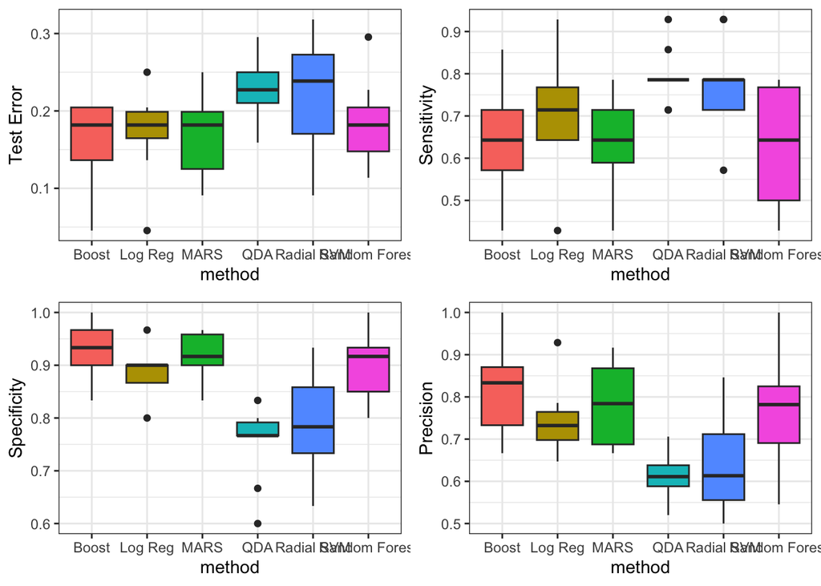

```r
tbr_top_mod_res <- rbind(glm_stats %>% mutate(method = "Log Reg"),
                     qda_stats %>% mutate(method = "QDA"),
                     boost_stats %>% mutate(method = "Boost"),
                     svm_stats %>% mutate(method = "Radial SVM"),
                     rf_stats %>% mutate(method = "Random Forest"),
                     mars_stats %>% mutate(method = "MARS"))
# plot results
r1 <- ggplot(tbr_top_mod_res, aes(x = method, y = test_error, fill = method))+
  geom_boxplot()+
  ylab("Test Error")+
  guides(fill = 'none')+
  theme_bw()

r2 <- ggplot(tbr_top_mod_res, aes(x = method, y = sensitivity, fill = method))+
  geom_boxplot()+
  ylab("Sensitivity")+
  guides(fill = 'none')+
  theme_bw()

r3 <- ggplot(tbr_top_mod_res, aes(x = method, y = specificity, fill = method))+
  geom_boxplot()+
  ylab("Specificity")+
  guides(fill = 'none')+
  theme_bw()

r4 <- ggplot(tbr_top_mod_res, aes(x = method, y = precision, fill = method))+
  geom_boxplot()+
  ylab("Precision")+
  guides(fill = 'none')+
  theme_bw()

plot_grid(r1, r2, r3, r4, nrow=2)
```

```r
# select the algorithms that consistently produce the best results: low test error, high precision

tbr_test_stats <- rbind(mars_stats %>% filter(sensitivity > 0.7 & test_error < 0.15) %>% mutate(method = "MARS"),
                        boost_stats %>% filter(sensitivity > 0.7 & test_error < 0.15) %>% mutate(method = "Boost"),
                        glm_stats %>% filter(sensitivity > 0.7 & test_error < 0.15) %>% mutate(method = "glm"))
tbr_test_stats
```

```
##   test_error sensitivity specificity precision index method
## 1 0.11363636   0.7142857   0.9666667 0.9090909     2   MARS
## 2 0.11363636   0.7857143   0.9333333 0.8461538     3   MARS
## 3 0.09090909   0.7857143   0.9666667 0.9166667     5   MARS
## 4 0.13636364   0.7142857   0.9333333 0.8333333     2  Boost
## 5 0.13636364   0.7142857   0.9333333 0.8333333     3  Boost
## 6 0.04545455   0.8571429   1.0000000 1.0000000     5  Boost
## 7 0.13636364   0.7857143   0.9000000 0.7857143     3    glm
## 8 0.04545455   0.9285714   0.9666667 0.9285714     5    glm
```

```r
# the index indicates the seed used to generate test and training datasets
# save the top performing models in a list

tbr_best <- list(glm_models[[3]], glm_models[[5]], boost_models[[2]], boost_models[[3]], boost_models[[5]], mars_models[[2]], mars_models[[3]], mars_models[[5]])

lapply(tbr_best, varImp)
```

```
## [[1]]
## glm variable importance
##
##                                 Overall
## `\\`Tb427VSG-2069|291-381\\``    100.00
## `\\`Tbb927VSG-1617|225-315\\``    89.76
## `\\`Tb427VSG-1343|225-315\\``     71.60
## `\\`Tbb1125VSG-4218|406-496\\``   68.96
## `\\`AF107887.1|270-360\\``        53.06
## `\\`Tbb1125VSG-4304|90-180\\``    49.21
## `\\`Tbb927VSG-1611|45-135\\``     43.34
## `\\`CAA85518.2|180-270\\``        35.55
## `\\`Tbb927VSG-1041|90-180\\``     29.14
## `\\`Tb427VSG-340|439-529\\``      25.40
## `\\`Tb427VSG-1596|225-315\\``     14.57
## `\\`Tbb1125VSG-2036|405-495\\``   12.80
## `\\`Tb427VSG-1214|315-405\\``      3.57
## `\\`Tbb1125VSG-4304|45-135\\``     0.00
##
## [[2]]
## glm variable importance
##
##                                 Overall
## `\\`AF107887.1|270-360\\``       100.00
## `\\`Tb427VSG-2069|291-381\\``     93.89
## `\\`Tbb1125VSG-4218|406-496\\``   92.75
## `\\`Tb427VSG-1343|225-315\\``     88.75
## `\\`Tbb927VSG-1617|225-315\\``    86.95
## `\\`CAA85518.2|180-270\\``        67.67
## `\\`Tbb927VSG-1041|90-180\\``     67.05
## `\\`Tb427VSG-1214|315-405\\``     58.67
## `\\`Tbb927VSG-1611|45-135\\``     38.02
## `\\`Tbb1125VSG-4304|90-180\\``    36.77
## `\\`Tbb1125VSG-2036|405-495\\``   17.34
## `\\`Tb427VSG-1596|225-315\\``     17.17
## `\\`Tb427VSG-340|439-529\\``      12.49
## `\\`Tbb1125VSG-4304|45-135\\``     0.00
##
## [[3]]
## glmboost variable importance
```

[output cut: 101 more lines]

```
## `Tbb927VSG-1617|225-315`    13.87
## `Tb427VSG-340|439-529`       0.00
##
## [[8]]
## earth variable importance
##
##                           Overall
## `CAA85518.2|180-270`       100.00
## `AF107887.1|270-360`        60.15
## `Tbb1125VSG-4218|406-496`   46.35
## `Tb427VSG-2069|291-381`     35.61
## `Tb427VSG-1343|225-315`     25.82
## `Tbb927VSG-1611|45-135`     17.38
## `Tbb927VSG-1617|225-315`    10.12
## `Tbb927VSG-1041|90-180`      0.00
```

```r
# %>% select(Pos, names, model) %>% dplyr::rename("Overall"="Pos")
final_tbr <- rbind(varImp(tbr_best[[1]])$importance %>% mutate(names=row.names(.), model = "glm_3"),
                   varImp(tbr_best[[2]])$importance %>% mutate(names=row.names(.), model = "glm_5"),
                   varImp(tbr_best[[3]])$importance %>% mutate(names=row.names(.), model = "boost_2"),
                   varImp(tbr_best[[4]])$importance %>% mutate(names=row.names(.), model = "boost_3"),
                   varImp(tbr_best[[5]])$importance %>% mutate(names=row.names(.), model = "boost_5"),
                   varImp(tbr_best[[6]])$importance %>% mutate(names=row.names(.), model = "MARS_2"),
                   varImp(tbr_best[[7]])$importance %>% mutate(names=row.names(.), model = "MARS_3"),
                   varImp(tbr_best[[8]])$importance %>% mutate(names=row.names(.), model = "MARS_5"))

final_tbr$names <- gsub("`", "", final_tbr$names) %>% gsub("\\\\", "", .)
final_tbr <- final_tbr %>% filter(Overall > 0)
```

Boost, glm, and MARS are now probably the best performing models. They have reasonably high sensitivity and specificity, have a relatively low test error, and maintain high precision/accuracy. for each iterated Boost and MARS model, extract the variables of high importance. These will become our short list of candidates to validate as possible diagnostic peptides.

## Tbg Models

```r
# filter the matrix to only include the tbg infected cohort and all endemic negative controls
Tbg_df <- data.frame(t(fc_mat[, c(grep("g", colnames(fc_mat)), grep("Cr", colnames(fc_mat)))]))
colnames(Tbg_df) <- rownames(fc_mat)

# add infection binary variable
Tbg_df$sample <- rownames(Tbg_df)
Tbg_status <- data.frame(sample = Tbg_df$sample)
Tbg_status$status <- case_when(grepl("C", Tbg_status$sample ) ~ "Neg",
                               TRUE ~ "Pos") %>% as.factor()

Tbg_df <- merge(Tbg_df, Tbg_status)

Tbg_samples <- Tbg_df$sample
Tbg_df <- Tbg_df %>% dplyr::select(-sample)
rownames(Tbg_df) <- Tbg_samples
```

There are way too many predictors for this to be efficient, even after filtering using significance testing.

**Caret Package: Recursive Feature Elimination**

- Step 1: Build a ML model on a training dataset and estimate the feature importances on the test dataset.
- Step 2: Keeping priority to the most important variables, iterate through by building models of given subset sizes, that is, subgroups of most important predictors determined from step 1. Ranking of the predictors is recalculated in each iteration.
- Step 3: The model performances are compared across different subset sizes to arrive at the optimal number and list of final predictors.

It can be implemented using the rfe() function and you have the flexibility to control what algorithm rfe uses and how it cross validates by defining the rfeControl()

```r
# make testing and training datasets
train_ind <- createDataPartition(Tbg_df$status, p = 0.8, list = F)
trainer_tbg <- Tbg_df[train_ind, c(Tbg_sig, ncol(Tbg_df))]
tester_tbg <- Tbg_df[-train_ind, c(Tbg_sig, ncol(Tbg_df))]

# recursive feature elimination (rfe)
# define the size of variable subsets the function should consider
subsets <- c(10, 15, 20, 50, 100, 200, 500)
ctrl <- rfeControl(functions = rfFuncs, #rfFuncs is random forest algorithm
                   method = "repeatedcv", #repeated cross-validation approach
                   repeats = 5, # the number of times it should be repeated (k)
                   verbose = FALSE)

lmProfile <- rfe(x=trainer_tbg[, -2001], y=trainer_tbg$status,
                 sizes = subsets,
                 rfeControl = ctrl)

lmProfile

# Optimal variables
rfe_optimal <- lmProfile$optVariables
```

Optimized variables from RFE were saved in a file

```r
rfe_optimal <- read_csv("FigureData/Tbg_RFE.csv", col_names = F, show_col_types = F) %>% .$X1
rf_opt <- match(rfe_optimal, Tbg_sig)
Tbg_df <- Tbg_df[ , c(Tbg_sig, ncol(Tbg_df))]

set.seed(1234)
train_ind <- createDataPartition(Tbg_df$status, p = 0.8, list = F)
trainer_tbg <- Tbg_df[train_ind, c(rf_opt, ncol(Tbg_df))]
tester_tbg <- Tbg_df[-train_ind, c(rf_opt, ncol(Tbg_df))]

# Train, tune, and select from these candidate predictors to build the model
# Define the training control
fitControl <- trainControl(
    method = 'repeatedcv', # repeated k-fold cross validation
    number = 5, # number of folds
    repeats = 10,
    savePredictions = 'final', # saves predictions for optimal tuning parameter
    classProbs = T, # should class probabilities be returned
    summaryFunction=twoClassSummary  # results summary function
)

# use lasso to choose predictors and then build models using logistic regression, lda, qda, knn
trainer_mat <- model.matrix(status ~ ., data = trainer_tbg)[, -1]
trainer_res <- trainer_tbg$status
y <- as.double(trainer_res) %>% replace(., . == 1, 0) %>% replace(., . == 2, 1)
tester_mat <- model.matrix(status ~., data = tester_tbg)[, -1]
tester_res <- tester_tbg$status
lasso_out <- glmnet(trainer_mat, trainer_res, alpha = 1, family = 'binomial')

# find best lambda by cross-validation
cv_out <- cv.glmnet(trainer_mat, y, alpha = 1)
bestlam <- cv_out$lambda.min
lasso_coeff <- predict(lasso_out, s = bestlam, newx = tester_mat, type = 'coefficients')[1:50, ]
which(lasso_coeff > 0) %>% names()
```

```
##  [1] "`Tb427VSG-2211|0-90`"      "`Tbb1125VSG-6504|0-90`"
##  [3] "`Tb427VSG-1426|270-360`"   "`Tbb1125VSG-2583|180-270`"
##  [5] "`Tbb1125VSG-246|45-135`"   "`Tbb927VSG-147|45-135`"
##  [7] "`Tb427VSG-6146|0-90`"      "`Tb427VSG-6609|90-180`"
##  [9] "`Tbb1125VSG-6008|45-135`"  "`Tb427VSG-1008|45-135`"
## [11] "`Tb427VSG-1015|90-180`"    "`Tbb1125VSG-1677|45-135`"
## [13] "`Tb427VSG-807|225-315`"    "`KC434512.1|45-135`"
## [15] "`Tb427VSG-3693|0-90`"
```

```r
features <- data.frame(feats = which(lasso_coeff > 0) %>% names())

# identify the best performing models
glm_stats <- data.frame(test_error = double(),
                        sensitivity = double(),
                        specificity = double(),
                        precision = double())
tbg_model_glm <- list()

for (i in 1:10){
  set.seed(i)
  ind <- createDataPartition(Tbg_df$status, p = 0.8, list = F)
  trainer <- Tbg_df[ind, c(rf_opt, ncol(Tbg_df))]
  tester <- Tbg_df[-ind, c(rf_opt, ncol(Tbg_df))]
  formula <- as.formula(paste("status ~ ", paste(features$feats, collapse = " + ")))
  mod <- train(formula, data = trainer_tbg, method = 'glm', metric = 'ROC', trControl = fitControl)
  preds <- predict(mod, tester)
  x <- ressummary(preds, tester$status) %>% mutate(index = i)
  glm_stats <- rbind(glm_stats, x)
  tbg_model_glm[[i]] <- mod
}
glm_stats
```

```
##    test_error sensitivity specificity precision index
## 1        0.04        0.90   1.0000000  1.000000     1
## 2        0.00        1.00   1.0000000  1.000000     2
## 3        0.00        1.00   1.0000000  1.000000     3
## 4        0.02        1.00   0.9666667  0.952381     4
## 5        0.00        1.00   1.0000000  1.000000     5
## 6        0.00        1.00   1.0000000  1.000000     6
## 7        0.02        0.95   1.0000000  1.000000     7
## 8        0.00        1.00   1.0000000  1.000000     8
## 9        0.04        0.95   0.9666667  0.950000     9
## 10       0.04        0.95   0.9666667  0.950000    10
```

```r
qda_stats <- data.frame(test_error = double(),
                        sensitivity = double(),
                        specificity = double(),
                        precision = double())
tbg_model_qda <- list()

for (i in 1:10){
  set.seed(i)
  ind <- createDataPartition(Tbg_df$status, p = 0.8, list = F)
  trainer <- Tbg_df[ind, c(rf_opt, ncol(Tbg_df))]
  tester <- Tbg_df[-ind, c(rf_opt, ncol(Tbg_df))]
  formula <- as.formula(paste("status ~ ", paste(features$feats, collapse = " + ")))
  mod <- train(formula, data = trainer, method = 'qda', metric = 'ROC', trControl = fitControl)
  preds <- predict(mod, tester)
  x <- ressummary(preds, tester$status)  %>% mutate(index = i)
  qda_stats <- rbind(qda_stats, x)
  tbg_model_qda[[i]] <- mod
}
qda_stats
```

```
##    test_error sensitivity specificity precision index
## 1        0.10           1   0.8333333 0.8000000     1
## 2        0.10           1   0.8333333 0.8000000     2
## 3        0.04           1   0.9333333 0.9090909     3
## 4        0.12           1   0.8000000 0.7692308     4
## 5        0.06           1   0.9000000 0.8695652     5
## 6        0.12           1   0.8000000 0.7692308     6
## 7        0.02           1   0.9666667 0.9523810     7
## 8        0.08           1   0.8666667 0.8333333     8
## 9        0.10           1   0.8333333 0.8000000     9
## 10       0.08           1   0.8666667 0.8333333    10
```

```r
lda_stats <- data.frame(test_error = double(),
                        sensitivity = double(),
                        specificity = double(),
                        precision = double())
tbg_model_lda <- list()

for (i in 1:10){
  set.seed(i)
  ind <- createDataPartition(Tbg_df$status, p = 0.8, list = F)
  trainer <- Tbg_df[ind, c(rf_opt, ncol(Tbg_df))]
  tester <- Tbg_df[-ind, c(rf_opt, ncol(Tbg_df))]
  formula <- as.formula(paste("status ~ ", paste(features$feats, collapse = " + ")))
  mod <- train(formula, data = trainer, method = 'lda', metric = 'ROC', trControl = fitControl)
  preds <- predict(mod, tester)
  x <- ressummary(preds, tester$status)  %>% mutate(index = i)
  lda_stats <- rbind(lda_stats, x)
  tbg_model_lda[[i]] <- mod
}
lda_stats
```

```
##    test_error sensitivity specificity precision index
## 1        0.04        0.90   1.0000000 1.0000000     1
## 2        0.04        0.90   1.0000000 1.0000000     2
## 3        0.02        0.95   1.0000000 1.0000000     3
## 4        0.06        0.85   1.0000000 1.0000000     4
## 5        0.00        1.00   1.0000000 1.0000000     5
## 6        0.06        0.90   0.9666667 0.9473684     6
## 7        0.04        0.90   1.0000000 1.0000000     7
## 8        0.04        0.90   1.0000000 1.0000000     8
## 9        0.06        0.85   1.0000000 1.0000000     9
## 10       0.06        0.85   1.0000000 1.0000000    10
```

```r
boost_stats <- data.frame(test_error = double(),
                        sensitivity = double(),
                        specificity = double(),
                        precision = double())
tbg_model_boost <- list()

for (i in 1:10){
  set.seed(i)
  ind <- createDataPartition(Tbg_df$status, p = 0.8, list = F)
  trainer <- Tbg_df[ind, c(rf_opt, ncol(Tbg_df))]
  tester <- Tbg_df[-ind, c(rf_opt, ncol(Tbg_df))]
  mod <- train(status ~ ., data = trainer, method = 'glmboost', tuneLength = 5, metric = 'ROC', trControl = fitControl)
  preds <- predict(mod, tester)
  x <- ressummary(preds, tester$status) %>% mutate(index = i)
  boost_stats <- rbind(boost_stats, x)
  tbg_model_boost[[i]] <- mod
}
boost_stats
```

```
##    test_error sensitivity specificity precision index
## 1        0.02        0.95   1.0000000 1.0000000     1
## 2        0.04        0.90   1.0000000 1.0000000     2
## 3        0.02        0.95   1.0000000 1.0000000     3
## 4        0.06        0.90   0.9666667 0.9473684     4
## 5        0.00        1.00   1.0000000 1.0000000     5
## 6        0.04        0.90   1.0000000 1.0000000     6
## 7        0.04        0.90   1.0000000 1.0000000     7
## 8        0.04        0.95   0.9666667 0.9500000     8
## 9        0.04        0.90   1.0000000 1.0000000     9
## 10       0.06        0.85   1.0000000 1.0000000    10
```

```r
svm_stats <- data.frame(test_error = double(),
                        sensitivity = double(),
                        specificity = double(),
                        precision = double())
tbg_model_svm <- list()

for (i in 1:10){
  set.seed(i)
  ind <- createDataPartition(Tbg_df$status, p = 0.8, list = F)
  trainer <- Tbg_df[ind, c(rf_opt, ncol(Tbg_df))]
  tester <- Tbg_df[-ind, c(rf_opt, ncol(Tbg_df))]
  mod <- train(status ~ ., data = trainer, method = 'svmRadial', tuneLength = 15, metric = 'ROC', trControl = fitControl)
  preds <- predict(mod, tester)
  x <- ressummary(preds, tester$status)  %>% mutate(index = i)
  svm_stats <- rbind(svm_stats, x)
  tbg_model_svm[[i]] <- mod
}
svm_stats
```

```
##    test_error sensitivity specificity precision index
## 1        0.04        0.95   0.9666667 0.9500000     1
## 2        0.04        1.00   0.9333333 0.9090909     2
## 3        0.04        1.00   0.9333333 0.9090909     3
## 4        0.04        1.00   0.9333333 0.9090909     4
## 5        0.00        1.00   1.0000000 1.0000000     5
## 6        0.06        1.00   0.9000000 0.8695652     6
## 7        0.06        0.95   0.9333333 0.9047619     7
## 8        0.10        1.00   0.8333333 0.8000000     8
## 9        0.02        1.00   0.9666667 0.9523810     9
## 10       0.04        0.95   0.9666667 0.9500000    10
```

```r
rf_stats <- data.frame(test_error = double(),
                        sensitivity = double(),
                        specificity = double(),
                        precision = double())
tbg_model_rf <- list()

for (i in 1:10){
  set.seed(i)
  ind <- createDataPartition(Tbg_df$status, p = 0.8, list = F)
  trainer <- Tbg_df[ind, c(rf_opt, ncol(Tbg_df))]
  tester <- Tbg_df[-ind, c(rf_opt, ncol(Tbg_df))]
  mod <- train(status ~ ., data = trainer, method = 'rf', tuneLength = 5, metric = 'ROC', trControl = fitControl)
  preds <- predict(mod, tester)
  x <- ressummary(preds, tester$status) %>% mutate(index = i)
  rf_stats <- rbind(rf_stats, x)
  tbg_model_rf[[i]] <- mod
}
rf_stats
```

```
##    test_error sensitivity specificity precision index
## 1        0.04        0.90           1         1     1
## 2        0.00        1.00           1         1     2
## 3        0.00        1.00           1         1     3
## 4        0.00        1.00           1         1     4
## 5        0.00        1.00           1         1     5
## 6        0.04        0.90           1         1     6
## 7        0.04        0.90           1         1     7
## 8        0.04        0.90           1         1     8
## 9        0.00        1.00           1         1     9
## 10       0.06        0.85           1         1    10
```

```r
mars_stats <- data.frame(test_error = double(),
                        sensitivity = double(),
                        specificity = double(),
                        precision = double())
tbg_model_mars <- list()

for (i in 1:10){
  set.seed(i)
  ind <- createDataPartition(Tbg_df$status, p = 0.8, list = F)
  trainer <- Tbg_df[ind, c(rf_opt, ncol(Tbg_df))]
  tester <- Tbg_df[-ind, c(rf_opt, ncol(Tbg_df))]
  mod <- train(status ~., data = trainer, method='earth', tuneLength = 10, metric = 'ROC', trControl = fitControl)
  preds <- predict(mod, tester)
  x <- ressummary(preds, tester$status) %>% mutate(index = i)
  mars_stats <- rbind(mars_stats, x)
  tbg_model_mars[[i]] <- mod
}
mars_stats
```

```
##    test_error sensitivity specificity precision index
## 1        0.02        0.95   1.0000000      1.00     1
## 2        0.02        0.95   1.0000000      1.00     2
## 3        0.02        0.95   1.0000000      1.00     3
## 4        0.04        0.95   0.9666667      0.95     4
## 5        0.04        0.95   0.9666667      0.95     5
## 6        0.04        0.95   0.9666667      0.95     6
## 7        0.02        0.95   1.0000000      1.00     7
## 8        0.02        0.95   1.0000000      1.00     8
## 9        0.02        0.95   1.0000000      1.00     9
## 10       0.08        0.80   1.0000000      1.00    10
```

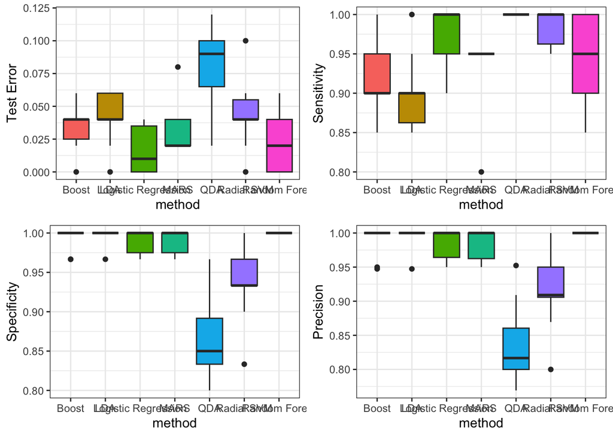

```r
tbg_top_mod_res <- rbind(glm_stats %>% mutate(method = "Logistic Regression"),
                     qda_stats %>% mutate(method = "QDA"),
                     lda_stats %>% mutate(method = "LDA"),
                     boost_stats %>% mutate(method = "Boost"),
                     svm_stats %>% mutate(method = "Radial SVM"),
                     rf_stats %>% mutate(method = "Random Forest"),
                     mars_stats %>% mutate(method = "MARS"))
# plot results
r1 <- ggplot(tbg_top_mod_res, aes(x = method, y = test_error, fill = method))+
  geom_boxplot()+
  ylab("Test Error")+
  guides(fill = 'none')+
  theme_bw()

r2 <- ggplot(tbg_top_mod_res, aes(x = method, y = sensitivity, fill = method))+
  geom_boxplot()+
  ylab("Sensitivity")+
  guides(fill = 'none')+
  theme_bw()

r3 <- ggplot(tbg_top_mod_res, aes(x = method, y = specificity, fill = method))+
  geom_boxplot()+
  ylab("Specificity")+
  guides(fill = 'none')+
  theme_bw()

r4 <- ggplot(tbg_top_mod_res, aes(x = method, y = precision, fill = method))+
  geom_boxplot()+
  ylab("Precision")+
  guides(fill = 'none')+
  theme_bw()

plot_grid(r1, r2, r3, r4, nrow=2)
```

```r
tbg_test_stats <- rbind(mars_stats %>% filter(sensitivity >= 0.95 & test_error < 0.025 & specificity == 1) %>% mutate(method = "MARS"),
                        boost_stats %>% filter(sensitivity >= 0.95 & test_error < 0.025 & specificity == 1) %>% mutate(method = "boost"),
                        glm_stats %>% filter(sensitivity >= 0.95 & test_error < 0.025 & specificity == 1) %>% mutate(method = "glm"),
                        lda_stats %>% filter(sensitivity >= 0.95 & test_error < 0.025 & specificity == 1) %>% mutate(method = "lda"))

# the index indicates the seed used to generate test and training datasets
# save the top performing models in a list
tbg_test_stats
```

```
##    test_error sensitivity specificity precision index method
## 1        0.02        0.95           1         1     1   MARS
## 2        0.02        0.95           1         1     2   MARS
## 3        0.02        0.95           1         1     3   MARS
## 4        0.02        0.95           1         1     7   MARS
## 5        0.02        0.95           1         1     8   MARS
## 6        0.02        0.95           1         1     9   MARS
## 7        0.02        0.95           1         1     1  boost
## 8        0.02        0.95           1         1     3  boost
## 9        0.00        1.00           1         1     5  boost
## 10       0.00        1.00           1         1     2    glm
## 11       0.00        1.00           1         1     3    glm
## 12       0.00        1.00           1         1     5    glm
## 13       0.00        1.00           1         1     6    glm
## 14       0.02        0.95           1         1     7    glm
## 15       0.00        1.00           1         1     8    glm
## 16       0.02        0.95           1         1     3    lda
## 17       0.00        1.00           1         1     5    lda
```

```r
# LDA and GLM both used the lasso selected peptides as predictors so they do not add too much, pick one of each as representatives

tbg_best <- list(tbg_model_glm[[2]], tbg_model_lda[[6]], tbg_model_boost[[1]], tbg_model_boost[[3]], tbg_model_boost[[5]], tbg_model_mars[[1]], tbg_model_mars[[2]], tbg_model_mars[[3]], tbg_model_mars[[7]], tbg_model_mars[[8]], tbg_model_mars[[9]])

final_tbg <- rbind(varImp(tbg_best[[1]])$importance %>% mutate(names=row.names(.), model = "glm_2"),
                   varImp(tbg_best[[2]])$importance %>% mutate(names=row.names(.), model = "lda_5") %>% dplyr::select(Pos, names, model) %>% dplyr::rename("Overall"="Pos"),
                   varImp(tbg_best[[3]])$importance %>% mutate(names=row.names(.), model = "boost_1"),
                   varImp(tbg_best[[4]])$importance %>% mutate(names=row.names(.), model = "boost_3"),
                   varImp(tbg_best[[5]])$importance %>% mutate(names=row.names(.), model = "boost_5"),
                   varImp(tbg_best[[6]])$importance %>% mutate(names=row.names(.), model = "MARS_1"),
                   varImp(tbg_best[[7]])$importance %>% mutate(names=row.names(.), model = "MARS_2"),
                   varImp(tbg_best[[8]])$importance %>% mutate(names=row.names(.), model = "MARS_3"),
                   varImp(tbg_best[[9]])$importance %>% mutate(names=row.names(.), model = "MARS_7"),
                   varImp(tbg_best[[10]])$importance %>% mutate(names=row.names(.), model = "MARS_8"),
                   varImp(tbg_best[[11]])$importance %>% mutate(names=row.names(.), model = "MARS_9"))

final_tbg$names <- gsub("`", "", final_tbg$names) %>% gsub("\\\\", "", .)
final_tbg <- final_tbg %>% filter(Overall > 0)
```

## Candidate Diagnostics

violin plots of signal distribution for candidate diagnostic peptides

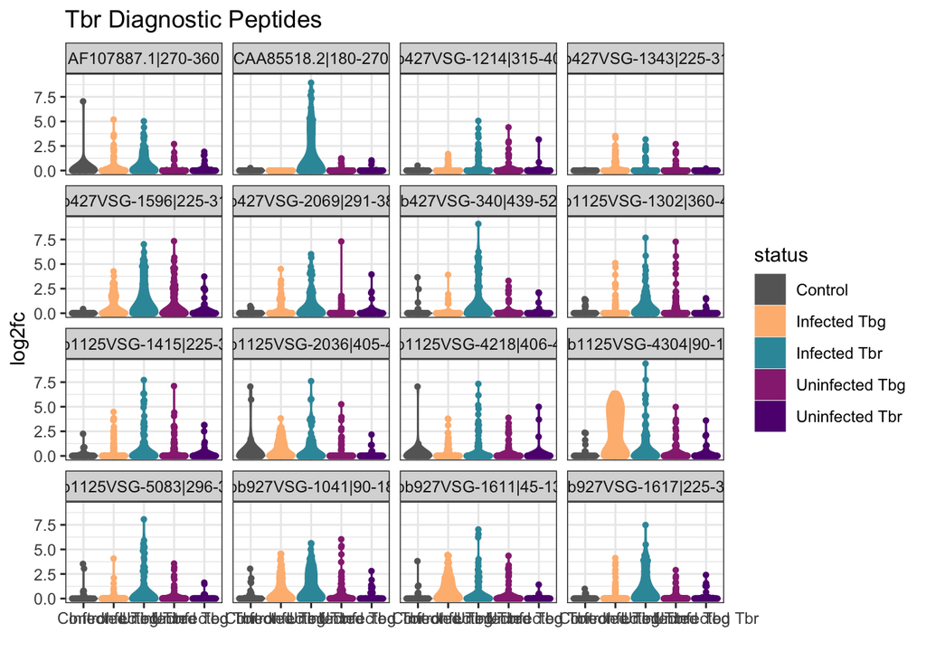

```r
# remove the apostrophes from the petides in the list so they match the dataframe peptide names

candidates <- candidates %>% mutate(status = case_when(grepl("Pr", sample)~"Infected Tbr",
                                         grepl("Cr", sample)~"Uninfected Tbr",
                                         grepl("Pg", sample)~"Infected Tbg",
                                         grepl("Cg", sample)~"Uninfected Tbg",
                                         grepl("NC", sample)~ "Control"))


candidates %>% filter(Peptide %in% unique(final_tbr$names)) %>%
  ggplot(aes(x = status, y = log2fc, fill = status, color = status))+
  geom_violin(scale = "width")+
  geom_quasirandom(size = 1)+
  facet_wrap(~Peptide)+
  scale_fill_manual(values = c("grey40", "#FEBA80FF", "#3497A9FF", "#982D80FF", "#5F187FFF"))+
  scale_color_manual(values = c("grey40", "#FEBA80FF", "#3497A9FF", "#982D80FF", "#5F187FFF"))+
  xlab("")+
  ggtitle("Tbr Diagnostic Peptides")+
  theme_bw()
```

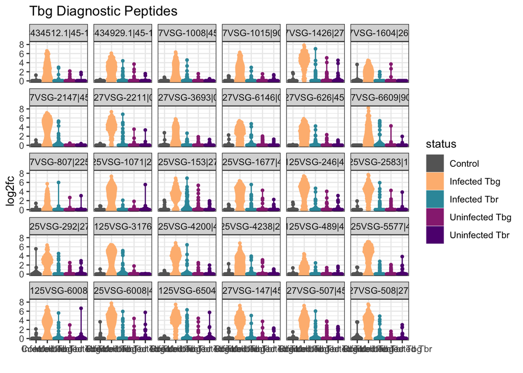

```r
candidates %>% filter(Peptide %in% unique(final_tbg$names)) %>%
  ggplot(aes(x = status, y = log2fc, fill = status, color = status))+
  geom_violin(scale = "width")+
  geom_quasirandom(size = 1)+
  facet_wrap(~Peptide)+
  scale_fill_manual(values = c("grey40", "#FEBA80FF", "#3497A9FF", "#982D80FF", "#5F187FFF"))+
  scale_color_manual(values = c("grey40", "#FEBA80FF", "#3497A9FF", "#982D80FF", "#5F187FFF"))+
  xlab("")+
  ggtitle("Tbg Diagnostic Peptides")+
  theme_bw()
```

## Peptide Types

Are the candidate tiles derived from A or B type VSGs?

```r
tile_info <- read_csv("FigureData/VSG_Tile_Classification.csv", show_col_types = F)

# tbg candidates: make sure they're not all B type or we will have same problem as the CATT
kbl(tile_info %>% filter(pep_id %in% unique(final_tbg$names)))
```

| pro_id | pep_id | pos_start | pos_end | pep_region | original_seq_length | nterm_seq_length | HMM_profile | nterm_typesubtype |
| --- | --- | --- | --- | --- | --- | --- | --- | --- |
| KC434512.1 | KC434512.1\|45-135 | 45 | 135 | N-terminal | 515 | 395 | VSG-N-TypeB | B1 |
| KC434929.1 | KC434929.1\|45-135 | 45 | 135 | N-terminal | 477 | 392 | VSG-N-TypeB | B1 |
| Tb427VSG-1008 | Tb427VSG-1008\|45-135 | 45 | 135 | N-terminal | 511 | 398 | VSG-N-TypeB | B1 |
| Tb427VSG-1015 | Tb427VSG-1015\|90-180 | 90 | 180 | N-terminal | 512 | 395 | VSG-N-TypeB | B1 |
| Tb427VSG-1426 | Tb427VSG-1426\|270-360 | 270 | 360 | N-terminal | 404 | 393 | VSG-N-TypeB | B1 |
| Tb427VSG-1604 | Tb427VSG-1604\|260-350 | 260 | 350 | N-terminal | 350 | 350 | VSG-N-TypeB | B1 |
| Tb427VSG-2147 | Tb427VSG-2147\|45-135 | 45 | 135 | N-terminal | 308 | 191 | VSG-N-TypeB | B1 |
| Tb427VSG-2211 | Tb427VSG-2211\|0-90 | 0 | 90 | N-terminal | 261 | 139 | VSG-N-TypeB | B1 |
| Tb427VSG-3693 | Tb427VSG-3693\|0-90 | 0 | 90 | N-terminal | 268 | 259 | VSG-N-TypeB | B1 |
| Tb427VSG-6146 | Tb427VSG-6146\|0-90 | 0 | 90 | N-terminal | 235 | 125 | VSG-N-TypeB | B1 |
| Tb427VSG-626 | Tb427VSG-626\|45-135 | 45 | 135 | N-terminal | 477 | 392 | VSG-N-TypeB | B1 |
| Tb427VSG-6609 | Tb427VSG-6609\|90-180 | 90 | 180 | Indeterminate | 199 | NA | None | Indeterminate |
| Tb427VSG-807 | Tb427VSG-807\|225-315 | 225 | 315 | N-terminal | 523 | 333 | VSG-N-TypeA | A2 |
| Tbb1125VSG-1071 | Tbb1125VSG-1071\|225-315 | 225 | 315 | N-terminal | 490 | 402 | VSG-N-TypeB | B1 |
| Tbb1125VSG-153 | Tbb1125VSG-153\|270-360 | 270 | 360 | N-terminal | 533 | 384 | VSG-N-TypeB | B1 |
| Tbb1125VSG-1677 | Tbb1125VSG-1677\|45-135 | 45 | 135 | N-terminal | 503 | 387 | VSG-N-TypeB | B1 |
| Tbb1125VSG-246 | Tbb1125VSG-246\|45-135 | 45 | 135 | N-terminal | 501 | 380 | VSG-N-TypeB | B1 |
| Tbb1125VSG-2583 | Tbb1125VSG-2583\|180-270 | 180 | 270 | N-terminal | 427 | 351 | VSG-N-TypeB | B1 |
| Tbb1125VSG-292 | Tbb1125VSG-292\|270-360 | 270 | 360 | N-terminal | 493 | 391 | VSG-N-TypeB | B1 |
| Tbb1125VSG-3176 | Tbb1125VSG-3176\|0-90 | 0 | 90 | N-terminal | 262 | 145 | VSG-N-TypeB | B1 |
| Tbb1125VSG-4200 | Tbb1125VSG-4200\|45-135 | 45 | 135 | N-terminal | 499 | 396 | VSG-N-TypeB | B1 |
| Tbb1125VSG-4238 | Tbb1125VSG-4238\|225-315 | 225 | 315 | N-terminal | 482 | 393 | VSG-N-TypeB | B1 |
| Tbb1125VSG-489 | Tbb1125VSG-489\|45-135 | 45 | 135 | N-terminal | 486 | 396 | VSG-N-TypeB | B1 |
| Tbb1125VSG-5577 | Tbb1125VSG-5577\|45-135 | 45 | 135 | N-terminal | 281 | 278 | VSG-N-TypeB | B1 |
| Tbb1125VSG-6008 | Tbb1125VSG-6008\|0-90 | 0 | 90 | N-terminal | 249 | 161 | VSG-N-TypeB | B1 |
| Tbb1125VSG-6008 | Tbb1125VSG-6008\|45-135 | 45 | 135 | N-terminal | 249 | 161 | VSG-N-TypeB | B1 |
| Tbb1125VSG-6504 | Tbb1125VSG-6504\|0-90 | 0 | 90 | N-terminal | 213 | 125 | VSG-N-TypeB | B1 |
| Tbb927VSG-147 | Tbb927VSG-147\|45-135 | 45 | 135 | N-terminal | 523 | 380 | VSG-N-TypeB | B1 |
| Tbb927VSG-507 | Tbb927VSG-507\|45-135 | 45 | 135 | N-terminal | 503 | 400 | VSG-N-TypeB | B1 |
| Tbb927VSG-508 | Tbb927VSG-508\|270-360 | 270 | 360 | N-terminal | 502 | 393 | VSG-N-TypeB | B1 |

```r
# they're almost all type B besides an undefined NTD and an A2

# tbr candidates
kbl(tile_info %>% filter(pep_id %in% unique(final_tbr$names)))
```

| pro_id | pep_id | pos_start | pos_end | pep_region | original_seq_length | nterm_seq_length | HMM_profile | nterm_typesubtype |
| --- | --- | --- | --- | --- | --- | --- | --- | --- |
| AF107887.1 | AF107887.1\|270-360 | 270 | 360 | Indeterminate | 400 | NA | None | Indeterminate |
| CAA85518.2 | CAA85518.2\|180-270 | 180 | 270 | C-terminal | 410 | 262 | VSG-N-TypeA | A2 |
| Tb427VSG-1214 | Tb427VSG-1214\|315-405 | 315 | 405 | C-terminal | 449 | 398 | VSG-N-TypeB | B1 |
| Tb427VSG-1343 | Tb427VSG-1343\|225-315 | 225 | 315 | N-terminal | 427 | 394 | VSG-N-TypeA | A2 |
| Tb427VSG-1596 | Tb427VSG-1596\|225-315 | 225 | 315 | N-terminal | 348 | 347 | VSG-N-TypeA | A2 |
| Tb427VSG-2069 | Tb427VSG-2069\|291-381 | 291 | 381 | C-terminal | 381 | 252 | VSG-N-TypeB | B1 |
| Tb427VSG-340 | Tb427VSG-340\|439-529 | 439 | 529 | C-terminal | 529 | 403 | VSG-N-TypeB | B1 |
| Tbb1125VSG-1302 | Tbb1125VSG-1302\|360-450 | 360 | 450 | C-terminal | 452 | 388 | VSG-N-TypeB | B1 |
| Tbb1125VSG-1415 | Tbb1125VSG-1415\|225-315 | 225 | 315 | C-terminal | 359 | 290 | VSG-N-TypeB | B1 |
| Tbb1125VSG-2036 | Tbb1125VSG-2036\|405-495 | 405 | 495 | C-terminal | 508 | 433 | VSG-N-TypeA | 1a |
| Tbb1125VSG-4218 | Tbb1125VSG-4218\|406-496 | 406 | 496 | C-terminal | 496 | 428 | VSG-N-TypeA | 1a |
| Tbb1125VSG-4304 | Tbb1125VSG-4304\|90-180 | 90 | 180 | N-terminal | 519 | 396 | VSG-N-TypeB | B1 |
| Tbb1125VSG-5083 | Tbb1125VSG-5083\|296-386 | 296 | 386 | C-terminal | 386 | 258 | VSG-N-TypeB | B1 |
| Tbb927VSG-1041 | Tbb927VSG-1041\|90-180 | 90 | 180 | N-terminal | 353 | 223 | VSG-N-DomainBoundary | A2 |
| Tbb927VSG-1611 | Tbb927VSG-1611\|45-135 | 45 | 135 | N-terminal | 349 | 320 | VSG-N-TypeA | 1a |
| Tbb927VSG-1617 | Tbb927VSG-1617\|225-315 | 225 | 315 | C-terminal | 342 | 262 | VSG-N-TypeB | B1 |

# A

Tbg ROC

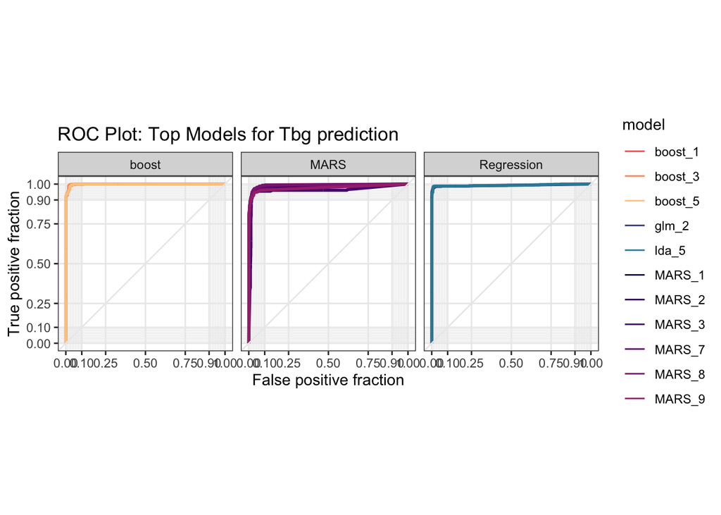

```r
# Plot ROC
tbg_roc_data <- data.frame()

for(i in 1:length(tbg_best)){
  x <- tbg_best[[i]]$pred %>% dplyr::select(pred, obs, rowIndex, Neg, Pos, Resample) %>% mutate(model_ind = i)
  tbg_roc_data <- rbind(tbg_roc_data, x)

}

tbg_roc_data$model <- case_when(tbg_roc_data$model_ind == 1 ~ "glm_2",
                                tbg_roc_data$model_ind == 2 ~ "lda_5",
                                tbg_roc_data$model_ind == 3 ~ "boost_1",
                                tbg_roc_data$model_ind == 4 ~ "boost_3",
                                tbg_roc_data$model_ind == 5 ~ "boost_5",
                                tbg_roc_data$model_ind == 6 ~ "MARS_1",
                                tbg_roc_data$model_ind == 7 ~ "MARS_2",
                                tbg_roc_data$model_ind == 8 ~ "MARS_3",
                                tbg_roc_data$model_ind == 9 ~ "MARS_7",
                                tbg_roc_data$model_ind == 10 ~ "MARS_8",
                                tbg_roc_data$model_ind == 11 ~ "MARS_9")
tbg_roc_data$method <- case_when(grepl("boost", tbg_roc_data$model) ~ "boost",
                                grepl("MARS", tbg_roc_data$model) ~ "MARS",
                                TRUE ~ "Regression")

tbg_ROC <- ggplot(tbg_roc_data,
       aes(m = Pos, d = factor(obs, levels = c("Neg", "Pos")), color = model)) +
  geom_roc(n.cuts=0) +
  coord_equal() +
  style_roc()+
  facet_wrap(~method)+
  scale_color_manual(values = c("#F1605DFF", "#FD9567FF", "#FEC98DFF", "#40498EFF", "#348AA6FF", "#20114BFF", "#3B0F70FF", "#57157EFF", "#721F81FF", "#8C2981FF", "#A8327DFF"))+
  ggtitle("ROC Plot: Top Models for Tbg prediction")
tbg_ROC
```

```r
calc_auc(tbg_ROC)
```

[output not shown]

# B

Tbr ROC

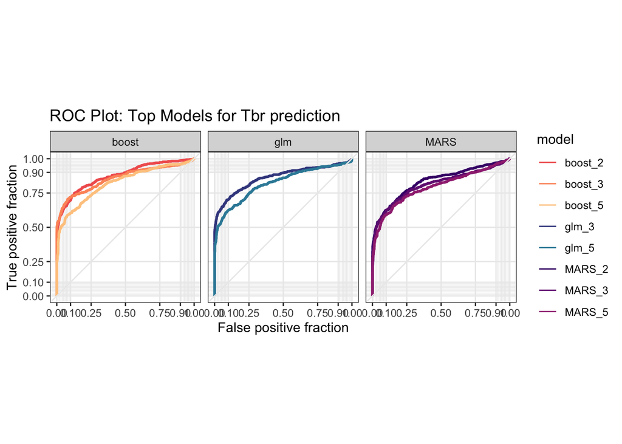

```r
# Plot ROC
tbr_roc_data <- data.frame()

for(i in 1:8){
  x <- tbr_best[[i]]$pred %>% dplyr::select(pred, obs, rowIndex, Neg, Pos, Resample) %>% mutate(model_ind = i)
  tbr_roc_data <- rbind(tbr_roc_data, x)

}

tbr_roc_data$model <- case_when(tbr_roc_data$model_ind == 1 ~ "glm_3",
                                tbr_roc_data$model_ind == 2 ~ "glm_5",
                                tbr_roc_data$model_ind == 3 ~ "boost_2",
                                tbr_roc_data$model_ind == 4 ~ "boost_3",
                                tbr_roc_data$model_ind == 5 ~ "boost_5",
                                tbr_roc_data$model_ind == 6 ~ "MARS_2",
                                tbr_roc_data$model_ind == 7 ~ "MARS_3",
                                tbr_roc_data$model_ind == 8 ~ "MARS_5")
tbr_roc_data$method <- case_when(grepl("glm", tbr_roc_data$model) ~ "glm",
                                grepl("boost", tbr_roc_data$model) ~ "boost",
                                grepl("MARS", tbr_roc_data$model) ~ "MARS")

tbr_ROC <- ggplot(tbr_roc_data,
       aes(m = Pos, d = factor(obs, levels = c("Neg", "Pos")), color = model)) +
  geom_roc(n.cuts=0) +
  coord_equal() +
  style_roc()+
  facet_wrap(~method)+
  scale_color_manual(values = c("#F1605DFF", "#FD9567FF", "#FEC98DFF", "#40498EFF", "#348AA6FF", "#451077FF", "#721F81FF", "#9F2F7FFF"))+
  ggtitle("ROC Plot: Top Models for Tbr prediction")
tbr_ROC
```

```r
calc_auc(tbr_ROC)
```

```
##   PANEL method COORD group   model       AUC
## 1     1  boost     1     1 boost_2 0.8759680
## 2     1  boost     1     2 boost_3 0.8566190
## 3     1  boost     1     3 boost_5 0.8221265
## 4     2    glm     1     4   glm_3 0.8621012
## 5     2    glm     1     5   glm_5 0.8216860
## 6     3   MARS     1     6  MARS_2 0.8328043
## 7     3   MARS     1     7  MARS_3 0.8099033
## 8     3   MARS     1     8  MARS_5 0.7935417
```

# C

Tbg heatmap

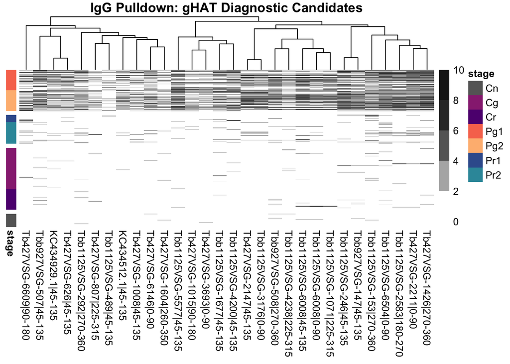

```r
key_rows <- HATmeta %>% dplyr::select(sample, stage)
key_rows$stage <- factor(key_rows$stage, levels = c("Pg1", "Pg2", "Pr1", "Pr2","Cg", "Cr", "Cn"))
key_rows <- key_rows %>% group_by(stage) %>% arrange(.by_group = T) %>% as.data.frame()
rownames(key_rows) <- key_rows$sample
key_rows <- key_rows[2]


tbg_mat <- t(fc_mat[unique(final_tbg$names), ]) %>% as.data.frame()

pheatmap(tbg_mat[rownames(key_rows), ],
         show_colnames= T,
         show_rownames = F,
         cluster_cols = T,
         cluster_rows = F,
         annotation_row = key_rows,
         gaps_row = c(100, 170, 320), #(head(as.numeric(cumsum(table(key_cols$Cohort))), -1)), this will split by all annotation groups
         breaks = c(0, 2, 4, 6, 8, 10),
         col = c("white", "grey70", "grey40", "grey20", "grey10", "black"),
         annotation_legend = TRUE,
         main = "IgG Pulldown: gHAT Diagnostic Candidates",
         annotation_colors = list(stage = c("Cn"="grey40",
                                            "Cg"="#982D80FF",
                                            "Cr"="#5F187FFF",
                                            "Pg1"="#f8765cff",
                                            "Pg2"="#FEBA80FF",
                                            "Pr1"="#395d9cff",
                                            "Pr2"="#3497A9FF"))
)
```

# D

Tbr heatmap

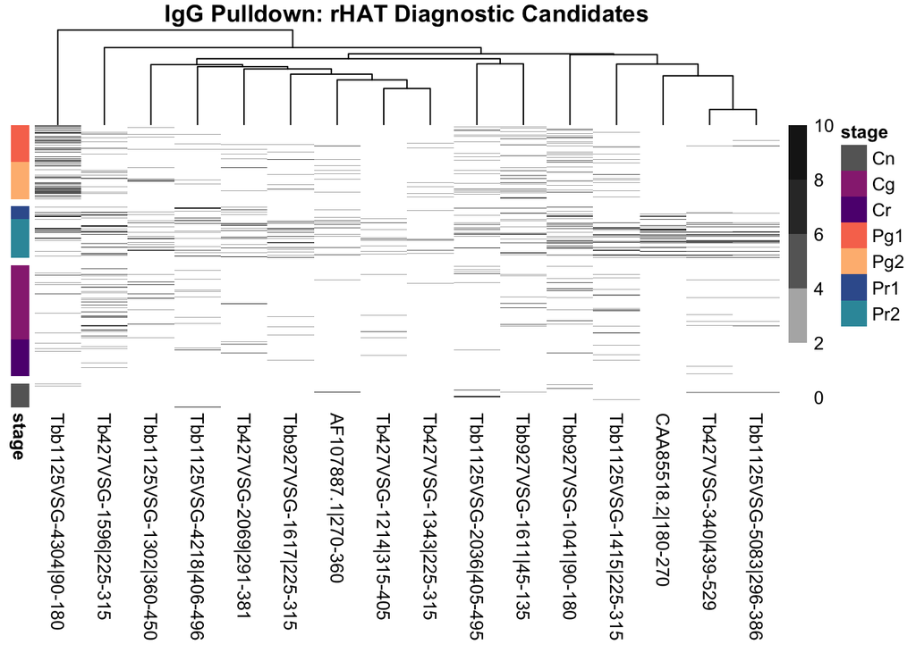

```r
tbr_mat <- t(fc_mat[unique(final_tbr$names), ]) %>% as.data.frame()


pheatmap(tbr_mat[rownames(key_rows), ],
         show_colnames= T,
         show_rownames = F,
         cluster_cols = T,
         cluster_rows = F,
         annotation_row = key_rows,
         gaps_row = c(100, 170, 320),#(head(as.numeric(cumsum(table(key_cols$Cohort))), -1)),
         breaks = c(0, 2, 4, 6, 8, 10),
         col = c("white", "grey70", "grey40", "grey20", "grey10", "black"),
         annotation_legend = TRUE,
         main = "IgG Pulldown: rHAT Diagnostic Candidates",
         annotation_colors = list(stage = c("Cn"="grey40",
                                            "Cg"="#982D80FF",
                                            "Cr"="#5F187FFF",
                                            "Pg1"="#f8765cff",
                                            "Pg2"="#FEBA80FF",
                                            "Pr1"="#395d9cff",
                                            "Pr2"="#3497A9FF"))
)
```

# E

re-code each heatmap matrix as binary positive or negative using different thresholds and count the number of positive peptides in controls vs patients. Define the threshold of detection as a log2(FC) > 2, this should be a reasonably strong signal.

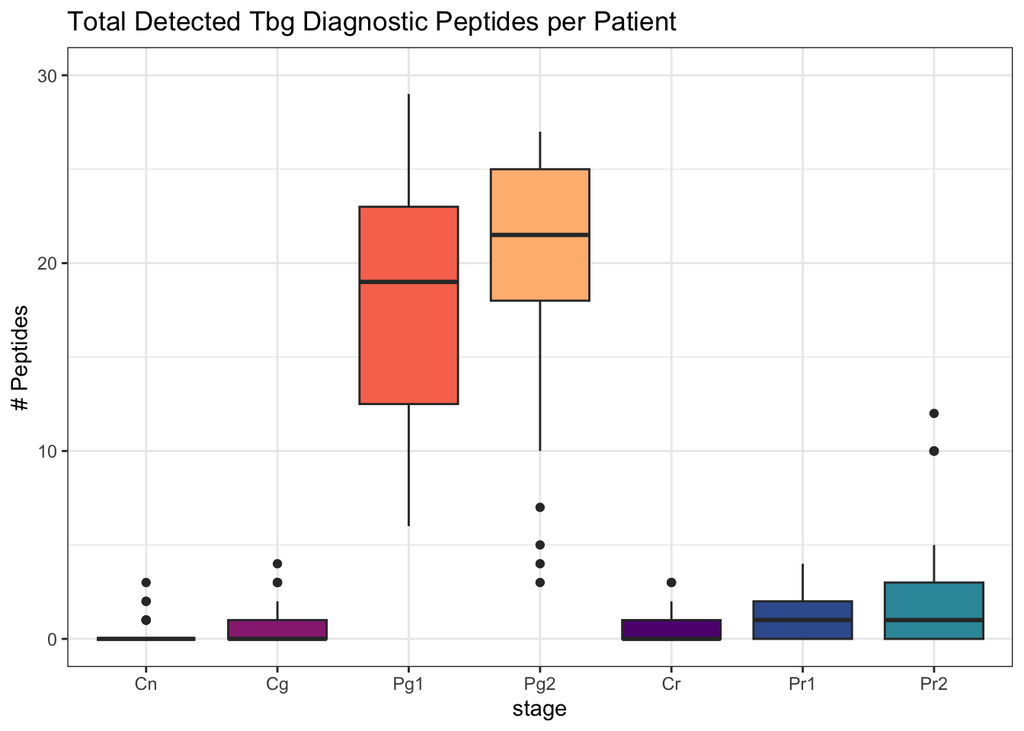

```r
# Tbg
tbg_mat_t2 <- tbg_mat
tbg_mat_t2[tbg_mat_t2 < 2] <- 0
tbg_mat_t2[tbg_mat_t2 >= 2] <- 1

tbg_diagnostic_t2 <- data.frame(value = rowSums(tbg_mat_t2),
                                sample = names(rowSums(tbg_mat_t2))) %>%
  inner_join(HATmeta, by = c("sample"))

tbg_diagnostic_t2$stage <- factor(tbg_diagnostic_t2$stage, levels = c("Cn", "Cg", "Pg1", "Pg2", "Cr", "Pr1", "Pr2"))

tbg_diagnostic_t2 %>%
  ggplot(aes(x = stage, y = value, fill = stage))+
  geom_boxplot()+
  scale_fill_manual(values = c("grey40","#982D80FF","#f8765cff","#FEBA80FF","#5F187FFF","#395d9cff","#3497A9FF"))+
  ggtitle("Total Detected Tbg Diagnostic Peptides per Patient")+
  ylab("# Peptides")+
  scale_y_continuous(limits = c(0, 30))+
  theme_bw()+
  theme(legend.position = "none")
```

# F

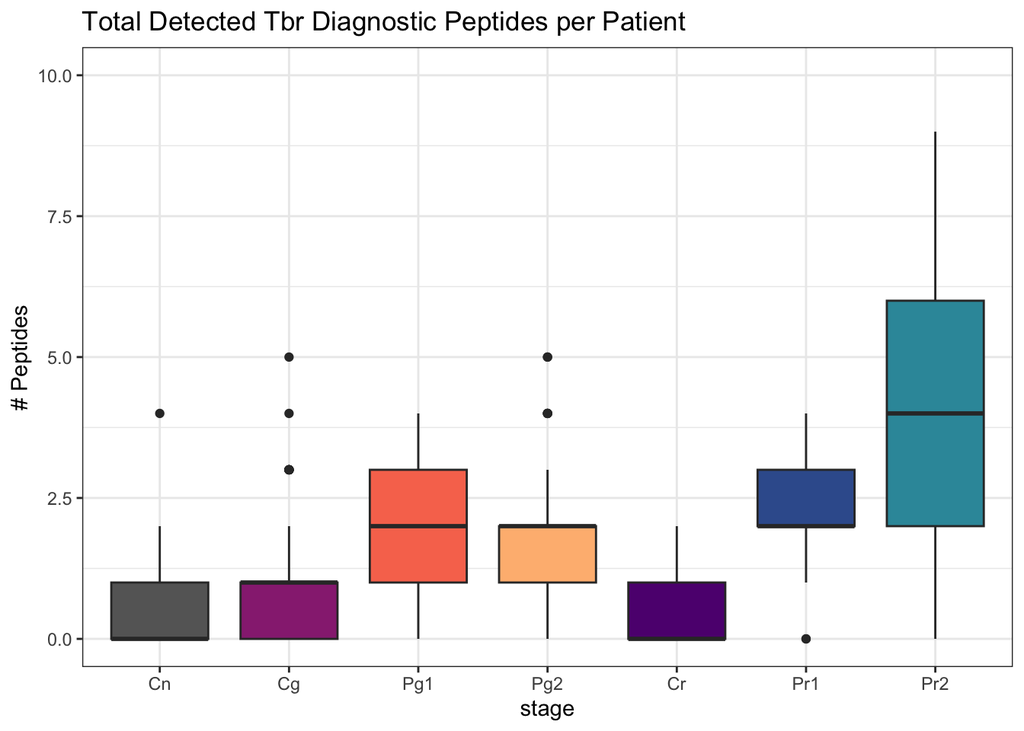

```r
# Tbr
tbr_mat_t2 <- tbr_mat
tbr_mat_t2[tbr_mat_t2 < 2] <- 0
tbr_mat_t2[tbr_mat_t2 >= 2] <- 1

tbr_diagnostic_t2 <- data.frame(value = rowSums(tbr_mat_t2),
                                sample = names(rowSums(tbr_mat_t2))) %>%
  inner_join(HATmeta, by = c("sample"))

tbr_diagnostic_t2$stage <- factor(tbr_diagnostic_t2$stage, levels = c("Cn", "Cg", "Pg1", "Pg2", "Cr", "Pr1", "Pr2"))

tbr_diagnostic_t2 %>%
  ggplot(aes(x = stage, y = value, fill = stage))+
  geom_boxplot()+
  scale_fill_manual(values = c("grey40","#982D80FF","#f8765cff","#FEBA80FF","#5F187FFF","#395d9cff","#3497A9FF"))+
  ggtitle("Total Detected Tbr Diagnostic Peptides per Patient")+
  ylab("# Peptides")+
  scale_y_continuous(limits = c(0, 10))+
  theme_bw()+
  theme(legend.position = "none")
```

# Supplemental Figures 6, 7, 8

## Permutation Testing

Compare the original ROC values to the distribution of random permuted values. The p-value is the proportion of times the randomized models performed as well or better than our trained model using real data.

### Tbg models

```r
# write functions to perform permutation tests for various models
# prepare tbg data for permutations
Tbg_perm_df <- data.frame(t(fc_mat[, c(grep("g", colnames(fc_mat)), grep("Cr", colnames(fc_mat)))]))
colnames(Tbg_perm_df) <- rownames(fc_mat)

# add infection binary variable
Tbg_perm_df$sample <- rownames(Tbg_perm_df)
Tbg_status <- data.frame(sample = Tbg_perm_df$sample)
Tbg_status$status <- case_when(grepl("C", Tbg_status$sample ) ~ "Neg",
                               TRUE ~ "Pos") %>% as.factor()

Tbg_perm_df <- merge(Tbg_perm_df, Tbg_status)
Tbg_samples <- Tbg_perm_df$sample
Tbg_perm_df <- Tbg_perm_df %>% dplyr::select(-sample)
rownames(Tbg_perm_df) <- Tbg_samples


permtbg_selected <- function(method_in){
  n_permutations <- 1000
  perm_metrics <- numeric(n_permutations)
  # set control for RFE
  ctrl <- rfeControl(functions = rfFuncs, #rfFuncs is random forest algorithm
                     method = "repeatedcv", #repeated cross-validation approach
                     repeats = 5, # the number of times it should be repeated (k)
                     verbose = FALSE)

  for(i in 1:n_permutations) {
    Tbg_shuffle <- data.frame(sample = rownames(Tbg_perm_df))
    Tbg_shuffle$status <- case_when(grepl("C", Tbg_shuffle$sample ) ~ "Neg",
                               TRUE ~ "Pos") %>% as.factor()
    # Shuffle the outcome variable
    shuffled_y <- sample(Tbg_shuffle$status)
    Tbg_shuffle$status <-  shuffled_y
    # perform wilcoxon ranked sum test
    Tbg_perm <- reshape2::melt(fc_mat, value.name = "log2fc") %>%
      dplyr::rename(c("Peptide"="Var1", "sample"="Var2")) %>% inner_join(Tbg_shuffle) %>%
      group_by(Peptide) %>% do(tidy(wilcox.test(log2fc~status, data = ., alternative = "greater")))
    # select the top 2000 peptides by p-value since that's the number used in the true model
    Tbg_perm_sig <- arrange(Tbg_perm, p.value) %>% .$Peptide %>% .[1:2000]
    # train the new model
    rownames(Tbg_shuffle) <- Tbg_shuffle$sample
    # create training dataset partition
    ind <- createDataPartition(Tbg_shuffle$status, p = 0.8, list = F)
    trainer <- Tbg_perm_df[ind, c(Tbg_perm_sig), drop = F] %>% cbind(Tbg_shuffle[ind,"status"])
    colnames(trainer)[length(Tbg_perm_sig)+1] <- "status"
    tester <- Tbg_perm_df[-ind, c(Tbg_perm_sig), drop = F] %>% cbind(Tbg_shuffle[-ind,"status"])
    colnames(tester)[length(Tbg_perm_sig)+1] <- "status"
    # recursive feature elimination (rfe)
    # define the size of variable subsets the function should consider
    subsets <- c(10, 15, 20, 50, 100, 200, 250)
    lmProfile <- rfe(x=trainer[, -2001], y=trainer$status,
                     sizes = subsets,
                     rfeControl = ctrl)
    # RFE optimal variables
    perm_rfe <- lmProfile$optVariables
    # make new test and train sets using RFE-selected variables
    trainer <- Tbg_perm_df[ind, c(perm_rfe), drop = F] %>% cbind(Tbg_shuffle[ind,"status"])
    colnames(trainer)[length(perm_rfe)+1] <- "status"
    tester <- Tbg_perm_df[-ind, c(perm_rfe), drop = F] %>% cbind(Tbg_shuffle[-ind,"status"])
    colnames(tester)[length(perm_rfe)+1] <- "status"
    trainer_mat <- model.matrix(status ~ ., data = trainer)[, -1]
    trainer_res <- trainer$status
    y <- as.double(trainer_res) %>% replace(., . == 1, 0) %>% replace(., . == 2, 1)
    tester_mat <- model.matrix(status ~., data = tester)[, -1]
    tester_res <- tester$status
    lasso_out <- glmnet(trainer_mat, trainer_res, alpha = 1, family = 'binomial')
    # find best lambda by cross-validation
    cv_out <- cv.glmnet(trainer_mat, y, alpha = 1)
    bestlam <- cv_out$lambda.min
    lasso_coeff <- predict(lasso_out, s = bestlam, newx = tester, type = 'coefficients')[1:length(perm_rfe), ]
    feature_coeff <- lasso_coeff[-1]
    if (length(feature_coeff[feature_coeff > 0]) > 0) {
    # Train model on shuffled data (use the same parameters as your original model)
    trainer_mat <- trainer_mat[, which(lasso_coeff > 0), drop = F]
    colnames(trainer_mat) <- which(lasso_coeff > 0) %>% names()
    perm_model <- train(x = trainer_mat,
                        y = trainer_res,
                        method = method_in,
                        # we used ROC (AUC) for model selection rather than accuracy or RMSE because our model is meant to predict a binary outcome
                        metric = 'ROC',
                        trControl = fitControl)
      perm_metrics[i] <- perm_model$results$ROC
    } else {
      # Assign ROC = 0.5 if no features pass lasso penalty
      # this is the value of a null, random guessing
      perm_metrics[i] <- 0.5
      }
    }
  return(perm_metrics)
}

# Tbg models that have built-in feature selection


permtbg <- function(method_in, my_model, seed){
  n_permutations <- 1000
  perm_metrics <- numeric(n_permutations)
  # set control for RFE
  ctrl <- rfeControl(functions = rfFuncs, #rfFuncs is random forest algorithm
                     method = "repeatedcv", #repeated cross-validation approach
                     repeats = 5, # the number of times it should be repeated (k)
                     verbose = FALSE)
  for(i in 1:n_permutations) {
    Tbg_shuffle <- data.frame(sample = rownames(Tbg_perm_df))
    Tbg_shuffle$status <- case_when(grepl("C", Tbg_shuffle$sample ) ~ "Neg",
                               TRUE ~ "Pos") %>% as.factor()
    # Shuffle the outcome variable
    shuffled_y <- sample(Tbg_shuffle$status)
    Tbg_shuffle$status <-  shuffled_y
    # perform wilcoxon ranked sum test
    Tbg_perm <- reshape2::melt(fc_mat, value.name = "log2fc") %>%
      dplyr::rename(c("Peptide"="Var1", "sample"="Var2")) %>% inner_join(Tbg_shuffle) %>%
      group_by(Peptide) %>% do(tidy(wilcox.test(log2fc~status, data = ., alternative = "greater")))
    # select the top 2000 peptides by p-value since that's the number used in the true model
    Tbg_perm_sig <- arrange(Tbg_perm, p.value) %>% .$Peptide %>% .[1:2000]
    # train the new model
    rownames(Tbg_shuffle) <- Tbg_shuffle$sample
    # create training dataset partition
    ind <- createDataPartition(Tbg_shuffle$status, p = 0.8, list = F)
    trainer <- Tbg_perm_df[ind, c(Tbg_perm_sig), drop = F] %>% cbind(Tbg_shuffle[ind,"status"])
    colnames(trainer)[length(Tbg_perm_sig)+1] <- "status"
    tester <- Tbg_perm_df[-ind, c(Tbg_perm_sig), drop = F] %>% cbind(Tbg_shuffle[-ind,"status"])
    colnames(tester)[length(Tbg_perm_sig)+1] <- "status"
    # recursive feature elimination (rfe)
    # define the size of variable subsets the function should consider
    subsets <- c(10, 15, 20, 50, 100, 200, 250)
    lmProfile <- rfe(x=trainer[, -2001], y=trainer$status,
                     sizes = subsets,
                     rfeControl = ctrl)
    # RFE optimal variables
    perm_rfe <- lmProfile$optVariables
    # make new test and train sets using RFE-selected variables
    trainer <- Tbg_perm_df[ind, c(perm_rfe), drop = F] %>% cbind(Tbg_shuffle[ind,"status"])
    colnames(trainer)[length(perm_rfe)+1] <- "status"
    tester <- Tbg_perm_df[-ind, c(perm_rfe), drop = F] %>% cbind(Tbg_shuffle[-ind,"status"])
    colnames(tester)[length(perm_rfe)+1] <- "status"
    # Train model on shuffled data (use the same parameters as your original model)
    perm_model <- train(status ~ .,
                        data = trainer,
                        method = method_in,
                        # we used ROC (AUC) for model selection rather than accuracy or RMSE because our model is meant to predict a binary outcome
                        metric = 'ROC',
                        trControl = fitControl)

    perm_metrics[i] <- perm_model$results$ROC
    }
  return(perm_metrics)
}

tbg1_metrics <- permtbg_selected('glm')
write_csv(as.data.frame(tbg1_metrics), file = "Tbg_glm_perm_res.txt", col_names = F)
tbg2_metrics <- permtbg('glmboost')
write_csv(as.data.frame(tbg2_metrics), file = "Tbg_boost_perm_res.txt", col_names = F)
tbg3_metrics <- permtbg('earth')
write_csv(as.data.frame(tbg3_metrics), file = "Tbg_MARS_perm_res.txt", col_names = F)
```

## S6A: Plot permutation results for Tbg

```r
# calculate p-values from permutation and observed ROC metrics
# we performed 1000 permutations with scrambled target columns
# the real model is counted as one of the permutations so add 1 to the numerator and denominator
tbg1_metrics <- read_csv("FigureData/Permutations/Tbg_glm_perm_res.txt", col_names = F, show_col_types = F) %>% .$X1
summary(tbg1_metrics)
```

```
##    Min. 1st Qu.  Median    Mean 3rd Qu.    Max.
##  0.5000  0.5000  0.5000  0.5053  0.5000  0.6940
```

```r
tbg_best[[1]]$results$ROC
```

```
## [1] 0.9922135
```

```r
sum(tbg1_metrics >= tbg_best[[1]]$results$ROC) + 1 / (1000 + 1)
```

```
## [1] 0.000999001
```

```r
tbg2_metrics <- read_csv("FigureData/Permutations/Tbg_boost_perm_res.txt", col_names = F, show_col_types = F) %>% .$X1
summary(tbg2_metrics)
```

```
##    Min. 1st Qu.  Median    Mean 3rd Qu.    Max.
##  0.4806  0.5811  0.6067  0.6085  0.6355  0.7387
```

```r
max(tbg_best[[3]]$results$ROC)
```

```
## [1] 0.9989583
```

```r
sum(tbg2_metrics >= max(tbg_best[[3]]$results$ROC)) + 1 / (1000 + 1)
```

```
## [1] 0.000999001
```

```r
tbg3_metrics <- read_csv("FigureData/Permutations/Tbg_MARS_perm_res.txt", col_names = F, show_col_types = F) %>% .$X1
summary(tbg3_metrics)
```

```
##    Min. 1st Qu.  Median    Mean 3rd Qu.    Max.
##  0.4504  0.4870  0.5013  0.5060  0.5174  0.6351
```

```r
max(tbg_best[[10]]$results$ROC)
```

```
## [1] 0.9941927
```

```r
sum(tbg3_metrics >= max(tbg_best[[10]]$results$ROC)) + 1 / (1000 + 1)
```

```
## [1] 0.000999001
```

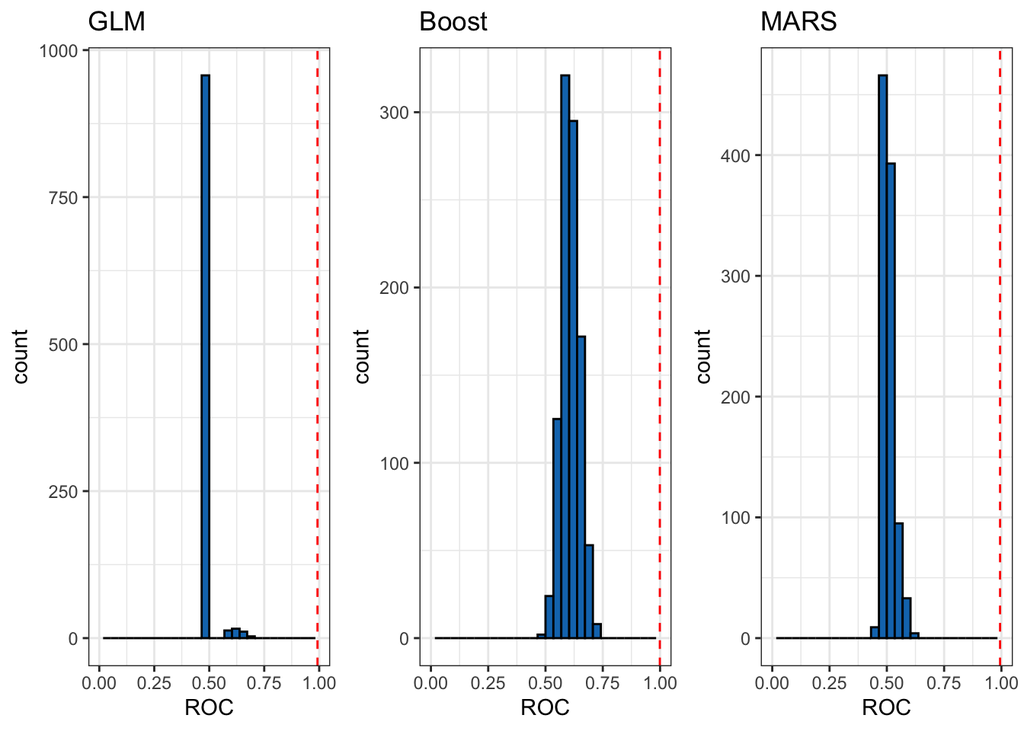

```r
plot_grid(
  data.frame(ROC = tbg1_metrics, method = rep("GLM", 1000)) %>%
  ggplot(aes(x = ROC)) +
  geom_histogram(fill = "#1177BB", color = "black") +
  geom_vline(xintercept = tbg_best[[1]]$results$ROC, lty = 2, color = "red") +
  theme_bw() +
  scale_x_continuous(limits = c(0,1)) +
  ggtitle("GLM"),
  data.frame(ROC = tbg2_metrics, method = rep("Boost", 1000)) %>%
  ggplot(aes(x = ROC)) +
  geom_histogram(fill = "#1177BB", color = "black") +
  geom_vline(xintercept = max(tbg_best[[3]]$results$ROC), lty = 2, color = "red") +
  theme_bw() +
  scale_x_continuous(limits = c(0,1)) +
  ggtitle("Boost"),
  data.frame(ROC = tbg3_metrics, method = rep("MARS", 1000)) %>%
  ggplot(aes(x = ROC)) +
  geom_histogram(fill = "#1177BB", color = "black") +
  geom_vline(xintercept = max(tbg_best[[10]]$results$ROC), lty = 2, color = "red") +
  theme_bw() +
  scale_x_continuous(limits = c(0,1)) +
  ggtitle("MARS"),
  nrow = 1
)
```

### Tbr Models

```r
# for tbr models that use lasso selected variables
permtbr_selected <- function(method_in){
  n_permutations <- 1000
  perm_metrics <- numeric(n_permutations)

  for(i in 1:n_permutations) {
    Tbr_shuffle <- data.frame(sample = rownames(Tbr_df))
    Tbr_shuffle$status <- case_when(grepl("C", Tbr_shuffle$sample ) ~ "Neg",
                               TRUE ~ "Pos") %>% as.factor()
    # Shuffle the outcome variable
    shuffled_y <- sample(Tbr_shuffle$status)
    Tbr_shuffle$status <-  shuffled_y
    # perform wilcoxon ranked sum test
    Tbr_perm <- reshape2::melt(fc_mat, value.name = "log2fc") %>%
      dplyr::rename(c("Peptide"="Var1", "sample"="Var2")) %>% inner_join(Tbr_shuffle) %>%
      group_by(Peptide) %>% do(tidy(wilcox.test(log2fc~status, data = ., alternative = "greater")))
    # select the top 24 peptides by p-value since that's the number used in the true model
    Tbr_perm_sig <- arrange(Tbr_perm, p.value) %>% .$Peptide %>% .[1:24]
    # train the new model
    rownames(Tbr_shuffle) <- Tbr_shuffle$sample
    # create training dataset partition
    ind <- createDataPartition(Tbr_shuffle$status, p = 0.8, list = F)
    trainer <- Tbr_df[ind, c(Tbr_perm_sig), drop = F] %>% cbind(Tbr_shuffle[ind,"status"])
    colnames(trainer)[length(Tbr_perm_sig)+1] <- "status"
    tester <- Tbr_df[-ind, c(Tbr_perm_sig), drop = F] %>% cbind(Tbr_shuffle[-ind,"status"])
    colnames(tester)[length(Tbr_perm_sig)+1] <- "status"
    trainer_mat <- model.matrix(status ~ ., data = trainer)[, -1]
    trainer_res <- trainer$status
    y <- as.double(trainer_res) %>% replace(., . == 1, 0) %>% replace(., . == 2, 1)
    tester_mat <- model.matrix(status ~., data = tester)[, -1]
    tester_res <- tester$status
    lasso_out <- glmnet(trainer_mat, trainer_res, alpha = 1, family = 'binomial')
    # find best lambda by cross-validation
    cv_out <- cv.glmnet(trainer_mat, y, alpha = 1)
    bestlam <- cv_out$lambda.min
    lasso_coeff <- predict(lasso_out, s = bestlam, newx = tester, type = 'coefficients')[1:length(Tbr_perm_sig), ]
    feature_coeff <- lasso_coeff[-1]
    if (length(feature_coeff[feature_coeff > 0]) > 0) {
    # Train model on shuffled data (use the same parameters as your original model)
    trainer_mat <- trainer_mat[, which(lasso_coeff > 0), drop = F]
    colnames(trainer_mat) <- which(lasso_coeff > 0) %>% names()
    perm_model <- train(x = trainer_mat,
                        y = trainer_res,
                        method = method_in,
                        # we used ROC (AUC) for model selection rather than accuracy or RMSE because our model is meant to predict a binary outcome
                        metric = 'ROC',
                        trControl = fitControl)
      perm_metrics[i] <- perm_model$results$ROC
    } else {
      # Assign ROC = 0.5 if no features pass lasso penalty
      # this is the value of a null, random guessing
      perm_metrics[i] <- 0.5
      }
    }
  return(perm_metrics)
}

permtbr <- function(method_in){
  n_permutations <- 1000
  perm_metrics <- numeric(n_permutations)
  for(i in 1:n_permutations) {
    Tbr_shuffle <- data.frame(sample = rownames(Tbr_df))
    Tbr_shuffle$status <- case_when(grepl("C", Tbr_shuffle$sample ) ~ "Neg",
                               TRUE ~ "Pos") %>% as.factor()
    # Shuffle the outcome variable
    shuffled_y <- sample(Tbr_shuffle$status)
    Tbr_shuffle$status <-  shuffled_y
    # perform wilcoxon ranked sum test
    Tbr_perm <- reshape2::melt(fc_mat, value.name = "log2fc") %>%
      dplyr::rename(c("Peptide"="Var1", "sample"="Var2")) %>% inner_join(Tbr_shuffle) %>%
      group_by(Peptide) %>% do(tidy(wilcox.test(log2fc~status, data = ., alternative = "greater")))
    # select the top 24 peptides by p-value since that's the number used in the true model
    Tbr_perm_sig <- arrange(Tbr_perm, p.value) %>% .$Peptide %>% .[1:24]
    # train the new model
    rownames(Tbr_shuffle) <- Tbr_shuffle$sample
    # create training dataset partition
    ind <- createDataPartition(Tbr_shuffle$status, p = 0.8, list = F)
    trainer <- Tbr_df[ind, c(Tbr_perm_sig), drop = F] %>% cbind(Tbr_shuffle[ind,"status"])
    colnames(trainer)[length(Tbr_perm_sig)+1] <- "status"
    tester <- Tbr_df[-ind, c(Tbr_perm_sig), drop = F] %>% cbind(Tbr_shuffle[-ind,"status"])
    colnames(tester)[length(Tbr_perm_sig)+1] <- "status"
    # Train model on shuffled data (use the same parameters as your original model)
    perm_model <- train(status ~ .,
                        data = trainer,
                        method = method_in,
                        # we used ROC (AUC) for model selection rather than accuracy or RMSE because our model is meant to predict a binary outcome
                        metric = 'ROC',
                        trControl = fitControl)

    perm_metrics[i] <- perm_model$results$ROC
    }
  return(perm_metrics)
}

tbr1_metrics <- permtbr_selected('glm')
write_csv(as.data.frame(tbr1_metrics), file = "Tbr_glm_perm_res.txt", col_names = F)
tbr2_metrics <- permtbr('glmboost')
write_csv(as.data.frame(tbr2_metrics), file = "Tbr_boost_perm_res.txt", col_names = F)
tbr3_metrics <- permtbr('earth')
write_csv(as.data.frame(tbr3_metrics), file = "Tbr_MARS_perm_res.txt", col_names = F)
```

## S6B: Plot permutation results for Tbr

```r
tbr1_metrics <- read_csv("FigureData/Permutations/Tbr_glm_perm_res.txt", col_names = F, show_col_types = F) %>% .$X1
summary(tbr1_metrics)
```

```
##    Min. 1st Qu.  Median    Mean 3rd Qu.    Max.
##  0.5000  0.5000  0.5000  0.5023  0.5000  0.6905
```

```r
tbr_best[[1]]$results$ROC
```

```
## [1] 0.8679672
```

```r
(sum(tbr1_metrics >= tbr_best[[1]]$results$ROC) + 1)/ (1000 + 1)
```

```
## [1] 0.000999001
```

```r
tbr2_metrics <- read_csv("FigureData/Permutations/Tbr_boost_perm_res.txt", col_names = F, show_col_types = F) %>% .$X1
summary(tbr2_metrics)
```

```
##    Min. 1st Qu.  Median    Mean 3rd Qu.    Max.
##  0.7015  0.7875  0.8136  0.8110  0.8361  0.8969
```

```r
max(tbr_best[[3]]$results$ROC)
```

```
## [1] 0.876029
```

```r
(sum(tbr2_metrics >= max(tbr_best[[3]]$results$ROC)) + 1)/ (1000 + 1)
```

```
## [1] 0.00999001
```

```r
tbr3_metrics <- read_csv("FigureData/Permutations/Tbr_MARS_perm_res.txt", col_names = F, show_col_types = F) %>% .$X1
summary(tbr3_metrics)
```

```
##    Min. 1st Qu.  Median    Mean 3rd Qu.    Max.
##  0.5003  0.5374  0.5499  0.5548  0.5660  0.7088
```

```r
max(tbr_best[[6]]$results$ROC)
```

```
## [1] 0.8342424
```

```r
(sum(tbr3_metrics >= max(tbr_best[[6]]$results$ROC)) + 1)/ (1000 + 1)
```

```
## [1] 0.000999001
```

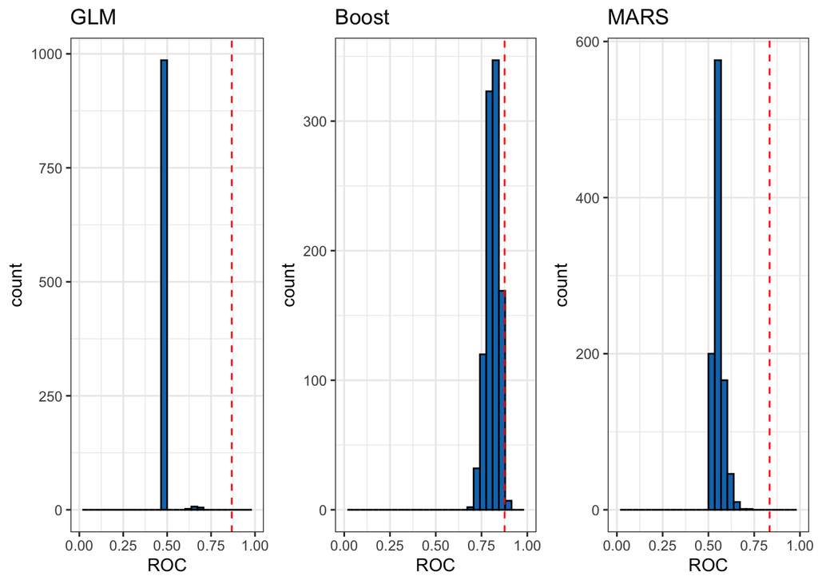

```r
plot_grid(
  data.frame(ROC = tbr1_metrics, method = rep("GLM", 1000)) %>%
  ggplot(aes(x = ROC)) +
  geom_histogram(fill = "#1177BB", color = "black") +
  geom_vline(xintercept = tbr_best[[1]]$results$ROC, lty = 2, color = "red") +
  theme_bw() +
  scale_x_continuous(limits = c(0,1)) +
  ggtitle("GLM"),
  data.frame(ROC = tbr2_metrics, method = rep("Boost", 1000)) %>%
  ggplot(aes(x = ROC)) +
  geom_histogram(fill = "#1177BB", color = "black") +
  geom_vline(xintercept = max(tbr_best[[3]]$results$ROC), lty = 2, color = "red") +
  theme_bw() +
  scale_x_continuous(limits = c(0,1)) +
  ggtitle("Boost"),
  data.frame(ROC = tbr3_metrics, method = rep("MARS", 1000)) %>%
  ggplot(aes(x = ROC)) +
  geom_histogram(fill = "#1177BB", color = "black") +
  geom_vline(xintercept = max(tbr_best[[6]]$results$ROC), lty = 2, color = "red") +
  theme_bw() +
  scale_x_continuous(limits = c(0,1)) +
  ggtitle("MARS"),
  nrow = 1
)
```

## S7A

rHAT predictive model variable importance

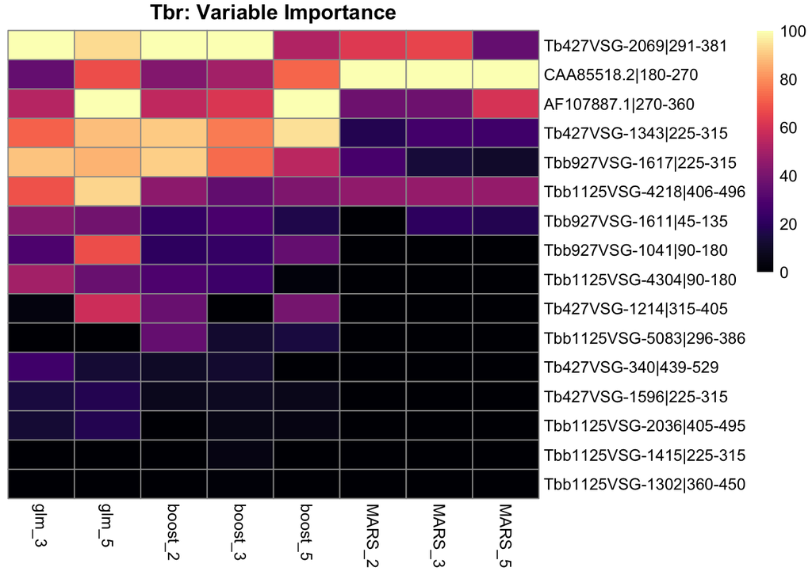

```r
hm_tbr <-
final_tbr %>% group_by(names) %>% mutate(temp = sum(Overall)) %>% arrange(-temp) %>% ungroup() %>% dplyr::select(model, names, Overall) %>% pivot_wider(names_from = "model", values_from = "Overall") %>% column_to_rownames(var = "names") %>% as.matrix(.)
hm_tbr[is.na(hm_tbr)] <- 0

pheatmap(hm_tbr,
         show_colnames= T,
         show_rownames = T,
         cluster_cols = F,
         cluster_rows = F,
         #breaks = c(0, 20, 40, 60, 80, 100),
         col = magma(100),
         main = "Tbr: Variable Importance"
         )
```

## S8A

gHAT predictive model variable importance

[figure not shown]

```r
hm_tbg <-
final_tbg %>% group_by(names) %>% mutate(temp = sum(Overall)) %>% arrange(-temp) %>% ungroup() %>% dplyr::select(model, names, Overall) %>% pivot_wider(names_from = "model", values_from = "Overall") %>% column_to_rownames(var = "names") %>% as.matrix(.)
hm_tbg[is.na(hm_tbg)] <- 0


pheatmap(hm_tbg,
         show_colnames= T,
         show_rownames = T,
         cluster_cols = F,
         cluster_rows = F,
         #breaks = c(0, 20, 40, 60, 80, 100),
         col = magma(100),
         main = "Tbr: Variable Importance"
         )
```

By [Jaime So](https://github.com/JSoSci/) for the [Hart Lab](https://www.the-hart-lab.com//)

*jso4@jhmi.edu*